# Best predictors based on XGBOOST (combination)

## 0. Package loading and installation

```python
# Commented out IPython magic to ensure Python compatibility.
# For Jupyter/Colab notebooks
%reset -f
import gc
gc.collect()

import numpy as np
import pandas as pd
import time

#conda install -c conda-forge \
#    numpy \
#    scipy \
#    pandas=2.2 \
#    pyarrow=15 \
#    scikit-survival \
#    spyder

# conda install -c conda-forge fastparquet
# conda install -c conda-forge xgboost
# conda install -c conda-forge pytorch cpuonly
# conda install -c pytorch pytorch cpuonly
# conda install -c conda-forge matplotlib
# conda install -c conda-forge seaborn
# conda install spyder-notebook -c spyder-ide
# conda install notebook nbformat nbconvert
# conda install -c conda-forge xlsxwriter
# conda install -c conda-forge shap

# import subprocess, sys

# subprocess.check_call([
#     sys.executable,
#     "-m",
#     "pip",
#     "install",
#     "matplotlib"
# ])

# subprocess.check_call([
#     sys.executable,
#     "-m",
#     "pip",
#     "install",
#     "seaborn"
# ])

print("numpy:", np.__version__)


from sksurv.metrics import (
    concordance_index_ipcw,
    brier_score,
    integrated_brier_score
)
from sksurv.util import Surv

#Dput
def dput_df(df, digits=6):
    data = {
        "columns": list(df.columns),
        "data": [
            [round(x, digits) if isinstance(x, (float, np.floating)) else x
             for x in row]
            for row in df.to_numpy()
        ]
    }
    print(data)


#Glimpse function
def glimpse(df, max_width=80):
    print(f"Rows: {df.shape[0]} | Columns: {df.shape[1]}")
    for col in df.columns:
        dtype = df[col].dtype
        preview = df[col].astype(str).head(5).tolist()
        preview_str = ", ".join(preview)
        if len(preview_str) > max_width:
            preview_str = preview_str[:max_width] + "..."
        print(f"{col:<30} {str(dtype):<15} {preview_str}")
#Tabyl function
def tabyl(series):
    counts = series.value_counts(dropna=False)
    props = series.value_counts(normalize=True, dropna=False)
    return pd.DataFrame({"value": counts.index,
                         "n": counts.values,
                         "percent": props.values})
#clean_names
import re

def clean_names(df):
    """
    Mimic janitor::clean_names for pandas DataFrames.
    - Lowercase
    - Replace spaces and special chars with underscores
    - Remove non-alphanumeric/underscore
    """
    new_cols = []
    for col in df.columns:
        # lowercase
        col = col.lower()
        # replace spaces and special chars with underscore
        col = re.sub(r"[^\w]+", "_", col)
        # strip leading/trailing underscores
        col = col.strip("_")
        new_cols.append(col)
    df.columns = new_cols
    return df
```

```
numpy: 2.0.1
```

## Load data

```python
from pathlib import Path

BASE_DIR = Path(
    r"G:\My Drive\Alvacast\SISTRAT 2023\data\20241015_out\pred1"
)


import pickle

with open(BASE_DIR / "imputations_list_jan26.pkl", "rb") as f:
    imputations_list_jan26 = pickle.load(f)


imputation_nodum_1 = pd.read_parquet(
    BASE_DIR / "imputation_nondum_1.parquet",
    engine="fastparquet"
)

X_reduced_imp0 = pd.read_parquet(
    BASE_DIR / "X_reduced_imp0.parquet",
    engine="fastparquet"
)

imputation_1 = pd.read_parquet(
    BASE_DIR / "imputation_1.parquet",
    engine="fastparquet"
)


# Quick check
glimpse(imputation_nodum_1)
glimpse(imputation_1)
glimpse(X_reduced_imp0)
```

```
Rows: 88504 | Columns: 41
readmit_time_from_adm_m        float64         84.93548387096774, 12.833333333333334, 13.733333333333333, 11.966666666666667, 1...
death_time_from_adm_m          float64         84.93548387096774, 87.16129032258064, 117.2258064516129, 98.93548387096774, 37.9...
adm_age_rec3                   float64         31.53, 20.61, 42.52, 60.61, 45.08
porc_pobr                      float64         0.175679117441177, 0.187835901975632, 0.130412444472313, 0.133759185671806, 0.08...
dit_m                          float64         15.967741935483872, 5.833333333333334, 0.4752688172043005, 6.966666666666667, 6....
sex_rec                        object          man, man, man, woman, man
tenure_status_household        object          stays temporarily with a relative, owner/transferred dwellings/pays dividends, s...
cohabitation                   object          alone, family of origin, with couple/children, with couple/children, family of o...
sub_dep_icd10_status           object          drug dependence, hazardous consumption, drug dependence, drug dependence, drug d...
any_violence                   object          0.No domestic violence/sex abuse, 0.No domestic violence/sex abuse, 0.No domesti...
prim_sub_freq_rec              object          2.2–6 days/wk, 3.Daily, 3.Daily, 3.Daily, 3.Daily
tr_outcome                     object          referral, dropout, adm discharge - rule violation/undet, dropout, completion
adm_motive                     object          sanitary sector, spontaneous consultation, sanitary sector, sanitary sector, spo...
first_sub_used                 object          alcohol, alcohol, alcohol, cocaine paste, alcohol
primary_sub_mod                object          alcohol, cocaine paste, cocaine paste, cocaine paste, cocaine paste
tipo_de_vivienda_rec2          object          other/unknown, formal housing, formal housing, formal housing, formal housing
national_foreign               int32           0, 0, 0, 0, 0
plan_type_corr                 object          pg-pab, pg-pab, pg-pr, m-pr, pg-pai
occupation_condition_corr24    object          unemployed, employed, employed, inactive, unemployed
marital_status_rec             object          single, single, single, married/cohabiting, single
urbanicity_cat                 object          3.Urban, 3.Urban, 3.Urban, 3.Urban, 3.Urban
ed_attainment_corr             object          2-Completed high school or less, 3-Completed primary school or less, 2-Completed...
evaluacindelprocesoteraputico  object          logro alto, logro minimo, logro minimo, logro minimo, logro alto
eva_consumo                    object          logro alto, logro minimo, logro minimo, logro intermedio, logro alto
eva_fam                        object          logro intermedio, logro minimo, logro minimo, logro intermedio, logro alto
eva_relinterp                  object          logro alto, logro minimo, logro minimo, logro intermedio, logro alto
eva_ocupacion                  object          logro alto, logro minimo, logro minimo, logro minimo, logro intermedio
eva_sm                         object          logro intermedio, logro minimo, logro minimo, logro intermedio, logro minimo
eva_fisica                     object          logro alto, logro minimo, logro intermedio, logro intermedio, logro alto
eva_transgnorma                object          logro alto, logro minimo, logro minimo, logro minimo, logro intermedio
ethnicity                      float64         0.0, 0.0, 0.0, 0.0, 0.0
dg_psiq_cie_10_instudy         bool            False, False, True, False, False
dg_psiq_cie_10_dg              bool            True, False, False, True, False
dx_f3_mood                     int32           0, 0, 0, 0, 0
dx_f6_personality              int32           0, 0, 0, 1, 0
dx_f_any_severe_mental         bool            True, False, False, False, False
any_phys_dx                    bool            False, False, False, True, False
polysubstance_strict           int32           0, 1, 1, 1, 1
readmit_event                  float64         0.0, 1.0, 1.0, 1.0, 1.0
```

[output cut: 190 more lines]

```
eva_sm_logro intermedio        bool            True, False, False, True, False
eva_sm_logro minimo            bool            False, True, True, False, True
eva_fisica_logro alto          bool            True, False, False, False, True
eva_fisica_logro intermedio    bool            False, False, True, True, False
eva_fisica_logro minimo        bool            False, True, False, False, False
eva_transgnorma_logro alto     bool            True, False, False, False, False
eva_transgnorma_logro intermedio bool            False, False, False, False, True
eva_transgnorma_logro minimo   bool            False, True, True, True, False
adm_age_cat_30-44              bool            True, False, True, False, False
adm_age_cat_45-64              bool            False, False, False, True, True
nationality_chile_other        bool            False, False, False, False, False
plan_type_corr_m-pr            bool            False, False, False, True, False
plan_type_corr_pg-pab          bool            True, True, False, False, False
plan_type_corr_pg-pai          bool            False, False, False, False, True
plan_type_corr_pg-pr           bool            False, False, True, False, False
```

```python
if isinstance(imputations_list_jan26, list) and len(imputations_list_jan26) > 0:
    print("First element type:", type(imputations_list_jan26[0]))
    if isinstance(imputations_list_jan26[0], dict):
        print("First element keys:", imputations_list_jan26[0].keys())
    elif isinstance(imputations_list_jan26[0], (pd.DataFrame, np.ndarray)):
        print("First element shape:", imputations_list_jan26[0].shape)
```

```
First element type: <class 'pandas.DataFrame'>
First element shape: (88504, 56)
```

This code block:

1. **Imports the `pickle` library**: This library implements binary protocols for serializing and de-serializing a Python object structure.
2. **Specifies the `file_path`**: It points to the `.pkl` file you selected.
3. **Opens the file in binary read mode (`'rb'`)**: This is necessary for loading pickle files.
4. **Loads the object**: `pickle.load(f)` reads the serialized object from the file and reconstructs it in memory.
5. **Prints confirmation and basic information**: It verifies that the file was loaded and shows the type of the loaded object, and some details about the first element if it's a list containing common data structures.

#### Compare databases (transformed and original)

Inspect and compare the column names of two datasets: the first imputation from imputations_list_jan26 (which likely contains dummy variables) and imputation_nodum_1 (which, as its name suggests, probably doesn't have dummy variables).

```python
# Inspect columns of the first imputation
cols_first_imp = imputations_list_jan26[0].columns.tolist()
print("First imputation columns:", cols_first_imp[:10], "... total:", len(cols_first_imp))

# Inspect columns of imputation_no_dum
cols_nodum = imputation_nodum_1.columns.tolist()
print("No-dum columns:", cols_nodum[:10], "... total:", len(cols_nodum))

# Compare overlap
common_cols = set(cols_first_imp).intersection(cols_nodum)
missing_in_imp = [c for c in cols_nodum if c not in cols_first_imp]
missing_in_nodum = [c for c in cols_first_imp if c not in cols_nodum]

print("Common columns:", len(common_cols))
print("Missing in imputations_list_jan26:", missing_in_imp)
```

```
First imputation columns: ['adm_age_rec3', 'porc_pobr', 'dit_m', 'tenure_status_household', 'prim_sub_freq_rec', 'national_foreign', 'urbanicity_cat', 'ed_attainment_corr', 'evaluacindelprocesoteraputico', 'eva_consumo'] ... total: 56
No-dum columns: ['readmit_time_from_adm_m', 'death_time_from_adm_m', 'adm_age_rec3', 'porc_pobr', 'dit_m', 'sex_rec', 'tenure_status_household', 'cohabitation', 'sub_dep_icd10_status', 'any_violence'] ... total: 41
Common columns: 24
Missing in imputations_list_jan26: ['readmit_time_from_adm_m', 'death_time_from_adm_m', 'sex_rec', 'cohabitation', 'sub_dep_icd10_status', 'any_violence', 'tr_outcome', 'adm_motive', 'first_sub_used', 'primary_sub_mod', 'tipo_de_vivienda_rec2', 'plan_type_corr', 'occupation_condition_corr24', 'marit…
```

```python
# Inspect columns of the first imputation
cols_first_imp_raw = imputation_1.columns.tolist()
print("First imputation columns:", cols_first_imp_raw[:10], "... total:", len(cols_first_imp_raw))

# Compare overlap
common_cols_raw = set(cols_first_imp_raw).intersection(cols_nodum)
missing_in_imp_raw = [c for c in cols_nodum if c not in cols_first_imp_raw]

print("Common columns:", len(common_cols_raw))
print("Missing in imputations_list_jan26:", missing_in_imp_raw)
print(common_cols_raw)
```

```
First imputation columns: ['readmit_time_from_adm_m', 'death_time_from_adm_m', 'adm_age_rec3', 'porc_pobr', 'dit_m', 'national_foreign', 'ethnicity', 'dg_psiq_cie_10_instudy', 'dg_psiq_cie_10_dg', 'dx_f3_mood'] ... total: 78
Common columns: 16
Missing in imputations_list_jan26: ['sex_rec', 'tenure_status_household', 'cohabitation', 'sub_dep_icd10_status', 'any_violence', 'prim_sub_freq_rec', 'tr_outcome', 'adm_motive', 'first_sub_used', 'primary_sub_mod', 'tipo_de_vivienda_rec2', 'plan_type_corr', 'occupation_condition_corr24', 'marital_s…
{'death_time_from_adm_m', 'porc_pobr', 'death_event', 'readmit_event', 'dg_psiq_cie_10_instudy', 'dg_psiq_cie_10_dg', 'readmit_time_from_adm_m', 'adm_age_rec3', 'polysubstance_strict', 'dx_f_any_severe_mental', 'national_foreign', 'any_phys_dx', 'ethnicity', 'dx_f6_personality', 'dit_m', 'dx_f3_mood…
```

```python
import pandas as pd

# Example: choose a combination of variables that uniquely identify rows
key_vars = ["adm_age_rec3", "porc_pobr", "dit_m"]

# Take one imputation (first element of the list) and merge with the no-dum dataset
df_imp = imputations_list_jan26[0]
df_nodum = imputation_nodum_1

merged_check = pd.merge(
    df_imp[key_vars],
    df_nodum[key_vars],
    on=key_vars,
    how="inner"
)

print(f"Merged rows: {merged_check.shape[0]}")
print("Preview of merged check:")
print(merged_check.head())

#drop merge
del merged_check
```

```
Merged rows: 88516
Preview of merged check:
   adm_age_rec3  porc_pobr      dit_m
0         31.53   0.175679  15.967742
1         20.61   0.187836   5.833333
2         42.52   0.130412   0.475269
3         60.61   0.133759   6.966667
4         45.08   0.083189   6.903226
```

```python
import pandas as pd

# Example: choose a combination of variables that uniquely identify rows
key_vars_raw = ['dit_m',
            'readmit_time_from_adm_m',
            'death_time_from_adm_m',
            'adm_age_rec3']
# Take one imputation (first element of the list) and merge with the no-dum dataset
df_raw = imputation_1

merged_check_raw = pd.merge(
    df_imp[key_vars],
    df_raw[key_vars],
    on=key_vars,
    how="inner"
)

print(f"Merged rows: {merged_check_raw.shape[0]}")
print("Preview of merged check:")
print(merged_check_raw.head())
print(f"{(merged_check_raw.shape[0] / imputation_1.shape[0] * 100):.2f}%")
#drop merge
del merged_check_raw
```

```
Merged rows: 88516
Preview of merged check:
   adm_age_rec3  porc_pobr      dit_m
0         31.53   0.175679  15.967742
1         20.61   0.187836   5.833333
2         42.52   0.130412   0.475269
3         60.61   0.133759   6.966667
4         45.08   0.083189   6.903226
100.01%
```

### Create bins for followup (landmarks)

This code prepares your data for survival analysis. It extracts the time until an event (like readmission or death) and whether that event actually happened for each patient from the df_nodum dataset. Then, it automatically creates a set of important time points, called an 'evaluation grid', which are specific moments to assess the model's performance on both readmission and death outcomes.

```python
import numpy as np

# Required columns for survival outcomes
required = ["readmit_time_from_disch_m", "readmit_event",
            "death_time_from_disch_m", "death_event"]

# Check that df_raw has all required columns
missing = [c for c in required if c not in df_raw.columns]
if missing:
    raise KeyError(f"df_nodum is missing columns: {missing}")

# Create time/event arrays directly from df_raw
time_readm = df_raw["readmit_time_from_adm_m"].to_numpy()
event_readm = (df_raw["readmit_event"].to_numpy() == 1)

time_death = df_raw["death_time_from_adm_m"].to_numpy()
event_death = (df_nodum["death_event"].to_numpy() == 1)

print("Arrays created for df_raw:")
print("Readmission times:", time_readm[:5])
print("Readmission events:", event_readm[:5])
print("Death times:", time_death[:5])
print("Death events:", event_death[:5])

# Build evaluation grids (quantiles of event times)
event_times_readm = time_readm[event_readm]
event_times_death = time_death[event_death]

if len(event_times_readm) < 5 or len(event_times_death) < 5:
    raise ValueError("Too few events in df_raw to build reliable time grids.")

times_eval_readm = np.unique(np.quantile(event_times_readm, np.linspace(0.05, 0.95, 50)))
times_eval_death = np.unique(np.quantile(event_times_death, np.linspace(0.05, 0.95, 50)))

print("Eval times (readmission):", times_eval_readm[:5], "...", times_eval_readm[-5:])
print("Eval times (death):", times_eval_death[:5], "...", times_eval_death[-5:])
```

```
Arrays created for df_raw:
Readmission times: [84.93548387 12.83333333 13.73333333 11.96666667 14.25806452]
Readmission events: [False  True  True  True  True]
Death times: [ 84.93548387  87.16129032 117.22580645  98.93548387  37.93548387]
Death events: [False False False False False]
Eval times (readmission): [3.93548387 4.77419355 5.45058701 6.06492649 6.67741935] ... [54.44173469 58.41566162 63.23333333 68.54767171 74.68983871]
Eval times (death): [4.16290323 5.43022383 6.68564845 8.24254115 9.77961817] ... [81.92700461 85.41186103 88.78518762 93.5538183  99.21935484]
```

## Prepare data

First, we eliminated inmortal time bias (dead patients look like without readmission).

This correction is essentially the Cause-Specific Hazard preparation. It is the correct way to handle Aim 3 unless you switch to a Fine-Gray model (which treats death as a specific type of event 2, rather than censoring 0). For RSF/Coxnet, censoring 0 is the correct approach.

```python
import numpy as np

# Step 1. Extract survival outcomes directly from df_raw
time_readm = df_raw["readmit_time_from_adm_m"].to_numpy()
event_readm = (df_raw["readmit_event"].to_numpy() == 1)

time_death = df_raw["death_time_from_adm_m"].to_numpy()
event_death = (df_raw["death_event"].to_numpy() == 1)

# Step 2. Build structured arrays (Surv objects)
y_surv_readm = np.empty(len(time_readm), dtype=[("event", "?"), ("time", "<f8")])
y_surv_readm["event"] = event_readm
y_surv_readm["time"] = time_readm

y_surv_death = np.empty(len(time_death), dtype=[("event", "?"), ("time", "<f8")])
y_surv_death["event"] = event_death
y_surv_death["time"] = time_death

# Step 3. Replicate across imputations
n_imputations = len(imputations_list_jan26)
y_surv_readm_list = [y_surv_readm for _ in range(n_imputations)]
y_surv_death_list = [y_surv_death for _ in range(n_imputations)]

import numpy as np

def correct_competing_risks(X_list, y_readm_list, y_death_list):
    """
    Adjust survival outcomes for competing risks (death vs. readmission).

    Parameters
    ----------
    X_list : list of pd.DataFrame
        Imputed predictor datasets (same rows across imputations).
    y_readm_list : list of structured arrays
        Surv(event, time) arrays for readmission.
    y_death_list : list of structured arrays
        Surv(event, time) arrays for death.

    Returns
    -------
    y_readm_corrected_list : list of structured arrays
        Corrected readmission outcomes (death treated as censoring).
    """
    corrected = []
    for y_readm, y_death in zip(y_readm_list, y_death_list):
        y_corr = y_readm.copy()
        # If patient died before readmission → censor at death time
        for i in range(len(y_corr)):
            if y_death["event"][i] and y_death["time"][i] < y_corr["time"][i]:
                y_corr["event"][i] = False
                y_corr["time"][i] = y_death["time"][i]
        corrected.append(y_corr)
    return corrected


# Step 4. Apply correction
y_surv_readm_list_corrected = correct_competing_risks(
    imputations_list_jan26,
    y_surv_readm_list,
    y_surv_death_list
)
```

```python
# Check type and length
type(y_surv_readm_list_corrected), len(y_surv_readm_list_corrected)

# Look at the first element
y_surv_readm_list_corrected[0][:5]   # first 5 rows
```

```
array([(False, 84.93548387), ( True, 12.83333333), ( True, 13.73333333),
       ( True, 11.96666667), ( True, 14.25806452)],
      dtype=[('event', '?'), ('time', '<f8')])
```

```python
glimpse(imputations_list_jan26[0])
print(y_surv_readm_list_corrected[0].shape, y_surv_readm_list_corrected[0].dtype)
```

```
Rows: 88504 | Columns: 56
adm_age_rec3                   float64         31.53, 20.61, 42.52, 60.61, 45.08
porc_pobr                      float64         0.175679117441177, 0.187835901975632, 0.130412444472313, 0.133759185671806, 0.08...
dit_m                          float64         15.967741935483872, 5.833333333333334, 0.4752688172043005, 6.966666666666667, 6....
tenure_status_household        int64           3, 0, 3, 0, 3
prim_sub_freq_rec              int64           1, 2, 2, 2, 2
national_foreign               int32           0, 0, 0, 0, 0
urbanicity_cat                 int64           0, 0, 0, 0, 0
ed_attainment_corr             float64         1.0, 2.0, 1.0, 1.0, 2.0
evaluacindelprocesoteraputico  int64           0, 2, 2, 2, 0
eva_consumo                    int64           0, 2, 2, 1, 0
eva_fam                        int64           1, 2, 2, 1, 0
eva_relinterp                  int64           0, 2, 2, 1, 0
eva_ocupacion                  int64           0, 2, 2, 2, 1
eva_sm                         int64           1, 2, 2, 1, 2
eva_fisica                     int64           0, 2, 1, 1, 0
eva_transgnorma                int64           0, 2, 2, 2, 1
ethnicity                      float64         0.0, 0.0, 0.0, 0.0, 0.0
dg_psiq_cie_10_instudy         bool            False, False, True, False, False
dg_psiq_cie_10_dg              bool            True, False, False, True, False
dx_f3_mood                     int32           0, 0, 0, 0, 0
dx_f6_personality              int32           0, 0, 0, 1, 0
dx_f_any_severe_mental         bool            True, False, False, False, False
any_phys_dx                    bool            False, False, False, True, False
polysubstance_strict           int32           0, 1, 1, 1, 1
sex_rec_woman                  float64         0.0, 0.0, 0.0, 1.0, 0.0
cohabitation_family_of_origin  float64         0.0, 1.0, 0.0, 0.0, 1.0
cohabitation_with_couple_children float64         0.0, 0.0, 1.0, 1.0, 0.0
cohabitation_others            float64         0.0, 0.0, 0.0, 0.0, 0.0
sub_dep_icd10_status_drug_dependence float64         1.0, 0.0, 1.0, 1.0, 1.0
any_violence_1_domestic_violence_sex_abuse float64         0.0, 0.0, 0.0, 0.0, 0.0
tr_outcome_referral            float64         1.0, 0.0, 0.0, 0.0, 0.0
tr_outcome_dropout             float64         0.0, 1.0, 0.0, 1.0, 0.0
tr_outcome_adm_discharge_rule_violation_undet float64         0.0, 0.0, 1.0, 0.0, 0.0
tr_outcome_adm_discharge_adm_reasons float64         0.0, 0.0, 0.0, 0.0, 0.0
tr_outcome_other               float64         0.0, 0.0, 0.0, 0.0, 0.0
adm_motive_sanitary_sector     float64         1.0, 0.0, 1.0, 1.0, 0.0
adm_motive_another_sud_facility_fonodrogas_senda_previene float64         0.0, 0.0, 0.0, 0.0, 0.0
adm_motive_justice_sector      float64         0.0, 0.0, 0.0, 0.0, 0.0
adm_motive_other               float64         0.0, 0.0, 0.0, 0.0, 0.0
first_sub_used_alcohol         float64         1.0, 1.0, 1.0, 0.0, 1.0
first_sub_used_cocaine_paste   float64         0.0, 0.0, 0.0, 1.0, 0.0
first_sub_used_cocaine_powder  float64         0.0, 0.0, 0.0, 0.0, 0.0
primary_sub_mod_cocaine_powder float64         0.0, 0.0, 0.0, 0.0, 0.0
primary_sub_mod_alcohol        float64         1.0, 0.0, 0.0, 0.0, 0.0
primary_sub_mod_marijuana      float64         0.0, 0.0, 0.0, 0.0, 0.0
primary_sub_mod_others         float64         0.0, 0.0, 0.0, 0.0, 0.0
tipo_de_vivienda_rec2_other_unknown float64         1.0, 0.0, 0.0, 0.0, 0.0
plan_type_corr_pg_pr           float64         0.0, 0.0, 1.0, 0.0, 0.0
plan_type_corr_m_pr            float64         0.0, 0.0, 0.0, 1.0, 0.0
plan_type_corr_pg_pai          float64         0.0, 0.0, 0.0, 0.0, 1.0
plan_type_corr_m_pai           float64         0.0, 0.0, 0.0, 0.0, 0.0
occupation_condition_corr24_unemployed float64         1.0, 0.0, 0.0, 0.0, 1.0
occupation_condition_corr24_inactive float64         0.0, 0.0, 0.0, 1.0, 0.0
marital_status_rec_single      float64         1.0, 1.0, 1.0, 0.0, 1.0
marital_status_rec_separated_divorced_annulled_widowed float64         0.0, 0.0, 0.0, 0.0, 0.0
first_sub_used_other           float64         0.0, 0.0, 0.0, 0.0, 0.0
(88504,) [('event', '?'), ('time', '<f8')]
```

# ML

### Advanced Survival Modeling: XGBoost & Stratified Evaluation

In this section, we transition to a Gradient Boosted Decision Tree (GBDT) framework using XGBoost. This approach serves as a robust, non-linear benchmark to validate findings from the neural network, specifically optimized for high-imbalance survival data (approx. 4% death rate).

### Full metric

The updated pipeline restricts evaluation to subjects at risk at each horizon, yielding discrimination measures consistent with Uno’s C-index.

1. Trains two XGBoost survival models: **death** and **readmission**.
2. Uses **K‑fold CV (K=10)** across multiple imputations for robust evaluation.
3. Labels encode survival for XGBoost as **time if event, -time if censored**.
4. Converts risk scores to survival **probabilities via Breslow**.
5. Computes **Uno’s C‑Index, IBS, Brier, and time‑dependent metrics** at many horizons.
6. Collects **CV‑SHAP** only for imputation 0 and aggregates SHAP across folds.
7. Applies **one‑hot encoding** (`pd.get_dummies`) before training.
8. Uses **early stopping** and large `num_boost_round` to avoid overfitting.
9. Clips predictions to ([-15,15]) to stabilize exponentiation in Breslow.
10. Saves artifacts: metrics CSV, raw logs, and aggregated SHAP pickle.
11. Stratifies folds by event and plan type to preserve cohort structure.
12. Heavy compute: multiple imputations × 10 folds × two models per fold.

```python
#@title ⚡ Step 5: Full XGBoost Analysis + Dual CV-SHAP (Readmission & Death)

import numpy as np
import pandas as pd
import xgboost as xgb
import pickle
import glob
import time
import gc
import copy
from datetime import datetime
from sklearn.model_selection import StratifiedKFold
from sklearn.metrics import brier_score_loss, f1_score, roc_curve, roc_auc_score, confusion_matrix
from sksurv.metrics import concordance_index_ipcw, integrated_brier_score

import warnings
warnings.filterwarnings("ignore")

print("⚠️ Starting Full XGBoost Analysis (Dual SHAP Accumulation)...")

# --- 0. CHECK FOR EXISTING FILE ---
existing_files = glob.glob("xgb6_DUAL_SHAP_Aggregated_*.pkl")

if existing_files:
    print(f"✅ Found existing analysis file: {existing_files[0]}")
    print("⏭️ Skipping computation.")

    try:
        latest_shap = sorted(glob.glob("xgb6_DUAL_SHAP_Aggregated_*.pkl"))[-1]
        with open(latest_shap, "rb") as f: shap_data_dual = pickle.load(f)

        # Try to find corresponding metrics file
        latest_csv = sorted(glob.glob("xgb6_DUAL_metrics_*.csv"))[-1]
        df_results = pd.read_csv(latest_csv)
        print("📦 Loaded all existing artifacts into memory.")
    except Exception as e:
        print(f"⚠️ Could not load artifacts: {e}")

else:
    start_time = time.time()

    # --- 1. CONFIGURATION ---
    # Assumes 'imputations_list_jan26', 'y_surv_death_list', 'y_surv_readm_list_corrected' are loaded
    N_IMPUTATIONS = len(imputations_list_jan26)
    K_FOLDS = 10
    TIMES_EVAL = [3, 6, 9, 12, 24, 36, 48, 60, 72, 84, 96, 108]
    SHAP_IMP_IDX = 0 # Calculate SHAP only for the first imputation

    # User Params
    BEST_PARAMS_r = {
        'objective': 'survival:cox', 'eval_metric': 'cox-nloglik', 'tree_method': 'hist', 'verbosity': 0,
        'learning_rate': 0.02, 'max_depth': 6, 'min_child_weight': 20, 'reg_alpha': 0.1, 'reg_lambda': 5.0,
        'subsample': 0.8, 'colsample_bytree': 0.7, 'gamma': 0.5, 'nthread': 29
    }
    BEST_PARAMS_d = {
        'objective': 'survival:cox', 'eval_metric': 'cox-nloglik', 'tree_method': 'hist', 'verbosity': 0,
        'learning_rate': 0.01, 'max_depth': 4, 'min_child_weight': 1, 'reg_alpha': 0.0, 'reg_lambda': 1.0,
        'subsample': 0.6, 'colsample_bytree': 0.8, 'gamma': 0.1, 'nthread': 29
    }

    # --- HELPER: Breslow ---
    def get_survival_probs_breslow(risk_train, risk_val, y_train_struc, time_grid):
        df_base = pd.DataFrame({'time': y_train_struc['time'], 'event': y_train_struc['event'], 'risk_score': np.exp(risk_train)})
        df_base = df_base.sort_values('time')
        unique_times = df_base['time'].unique()
        risk_sum = df_base['risk_score'][::-1].cumsum()[::-1]
        event_counts = df_base.groupby('time')['event'].sum()

        cum_hazard = 0
        h0_times = []
        h0_vals = []

        for t in unique_times:
            if t in event_counts.index:
                deaths = event_counts.loc[t]
                idx = df_base['time'].searchsorted(t, side='left')
                total_risk = risk_sum.iloc[idx]
                if total_risk > 0:
                    cum_hazard += deaths / total_risk
            h0_times.append(t)
            h0_vals.append(cum_hazard)

        h0_interp = np.interp(time_grid, h0_times, h0_vals)
        surv_probs = np.exp(-np.outer(np.exp(risk_val), h0_interp))
        return np.nan_to_num(surv_probs, nan=0.0)

    # --- HELPER: Binary Target ---
    def get_binary_target_bool(event_bool_va, times_va, t_horizon):
        is_case = (event_bool_va == True) & (times_va <= t_horizon)
        is_control = (times_va > t_horizon)
        valid_mask = is_case | is_control
        return is_case[valid_mask].astype(int), valid_mask

    def get_metrics_at_threshold(y_true, probas):
        probas = np.nan_to_num(probas, nan=0.0)
        if len(np.unique(y_true)) < 2: return {k: np.nan for k in ['Sens', 'Spec', 'PPV', 'NPV', 'F1']}
        fpr, tpr, thresholds = roc_curve(y_true, probas)
        idx = np.argmax(tpr - fpr)
        y_pred = (probas >= thresholds[idx]).astype(int)
        tn, fp, fn, tp = confusion_matrix(y_true, y_pred, labels=[0,1]).ravel()
        with np.errstate(divide='ignore', invalid='ignore'):
            return {
                'Sens': tp/(tp+fn) if (tp+fn)>0 else 0,
                'Spec': tn/(tn+fp) if (tn+fp)>0 else 0,
                'PPV': tp/(tp+fp) if (tp+fp)>0 else 0,
                'NPV': tn/(tn+fn) if (tn+fn)>0 else 0,
                'F1': f1_score(y_true, y_pred)
            }

    # --- MAIN PIPELINE ---
    metrics_log = []
    raw_data_log = []

    # DUAL SHAP CONTAINERS
    cv_shap_r = [] # Readmission
    cv_shap_d = [] # Death
    cv_X_val = []

    for imp_idx in range(N_IMPUTATIONS):
        X_raw = imputations_list_jan26[imp_idx]
        X_curr = pd.get_dummies(X_raw, drop_first=True).astype('float32')
        y_d = y_surv_death_list[imp_idx]
        y_r = y_surv_readm_list_corrected[imp_idx]

        t_d_full = y_d['time'] if isinstance(y_d['time'], np.ndarray) else y_d['time'].values
        e_d_full = y_d['event'] if isinstance(y_d['event'], np.ndarray) else y_d['event'].values.astype(bool)
        t_r_full = y_r['time'] if isinstance(y_r['time'], np.ndarray) else y_r['time'].values
        e_r_full = y_r['event'] if isinstance(y_r['event'], np.ndarray) else y_r['event'].values.astype(bool)

        # Stratification
        plan_labels = np.zeros(len(X_curr), dtype=int)
        if 'plan_type_corr_pg_pr' in X_curr.columns: plan_labels[X_curr['plan_type_corr_pg_pr'] == 1] = 1
        if 'plan_type_corr_m_pr' in X_curr.columns: plan_labels[X_curr['plan_type_corr_m_pr'] == 1] = 2
        if 'plan_type_corr_pg_pai' in X_curr.columns: plan_labels[X_curr['plan_type_corr_pg_pai'] == 1] = 3
        if 'plan_type_corr_m_pai' in X_curr.columns: plan_labels[X_curr['plan_type_corr_m_pai'] == 1] = 4

        strat_vector = e_r_full.astype(int)
        strat_labels = (strat_vector * 10) + plan_labels

        print(f"\n📂 Imp {imp_idx + 1}/{N_IMPUTATIONS}: ", end="")
        skf = StratifiedKFold(n_splits=K_FOLDS, shuffle=True, random_state=2125)
```

```python
        for fold_idx, (train_idx, val_idx) in enumerate(skf.split(X_curr, strat_labels)):
            X_tr, X_va = X_curr.iloc[train_idx], X_curr.iloc[val_idx]

            # --- SUBSET ARRAYS ---
            t_d_tr, e_d_tr = t_d_full[train_idx], e_d_full[train_idx]
            t_d_va, e_d_va = t_d_full[val_idx], e_d_full[val_idx]

            t_r_tr, e_r_tr = t_r_full[train_idx], e_r_full[train_idx]
            t_r_va, e_r_va = t_r_full[val_idx], e_r_full[val_idx]

            # --- DEATH MODEL ---
            y_xgb_d_tr = np.where(e_d_tr, t_d_tr, -t_d_tr)
            y_xgb_d_va = np.where(e_d_va, t_d_va, -t_d_va)
            dtrain_d = xgb.DMatrix(X_tr, label=y_xgb_d_tr); dval_d = xgb.DMatrix(X_va, label=y_xgb_d_va)
            model_d = xgb.train(BEST_PARAMS_d, dtrain_d, num_boost_round=5000, evals=[(dval_d, 'val')], early_stopping_rounds=100, verbose_eval=False)

            # --- READMISSION MODEL ---
            y_xgb_r_tr = np.where(e_r_tr, t_r_tr, -t_r_tr)
            y_xgb_r_va = np.where(e_r_va, t_r_va, -t_r_va)
            dtrain_r = xgb.DMatrix(X_tr, label=y_xgb_r_tr); dval_r = xgb.DMatrix(X_va, label=y_xgb_r_va)
            model_r = xgb.train(BEST_PARAMS_r, dtrain_r, num_boost_round=5000, evals=[(dval_r, 'val')], early_stopping_rounds=100, verbose_eval=False)

            # --- 🌟 DUAL SHAP ACCUMULATION ---
            if imp_idx == SHAP_IMP_IDX:
                # Readmission SHAP
                explainer_r = shap.TreeExplainer(model_r)
                cv_shap_r.append(explainer_r.shap_values(X_va))

                # Death SHAP
                explainer_d = shap.TreeExplainer(model_d)
                cv_shap_d.append(explainer_d.shap_values(X_va))

                cv_X_val.append(X_va)

            # --- PREDICTIONS & METRICS ---
            risk_d_tr = np.clip(model_d.predict(dtrain_d), -15, 15)
            risk_d_val = np.clip(model_d.predict(dval_d), -15, 15)
            risk_r_tr = np.clip(model_r.predict(dtrain_r), -15, 15)
            risk_r_val = np.clip(model_r.predict(dval_r), -15, 15)

            # Original Validation Arrays
            y_tr_struc_d = y_d[train_idx]
            y_va_struc_d = y_d[val_idx]
            y_tr_struc_r = y_r[train_idx]
            y_va_struc_r = y_r[val_idx]

            # 1. Global C-Index
            try:
                c_idx_d = concordance_index_ipcw(y_tr_struc_d, y_va_struc_d, risk_d_val)[0]
                metrics_log.append({'Imp': imp_idx, 'Fold': fold_idx, 'Risk': 'Death', 'Metric': "Uno's C-Index", 'Time': 'Global', 'Value': c_idx_d})
                c_idx_r = concordance_index_ipcw(y_tr_struc_r, y_va_struc_r, risk_r_val)[0]
                metrics_log.append({'Imp': imp_idx, 'Fold': fold_idx, 'Risk': 'Readmission', 'Metric': "Uno's C-Index", 'Time': 'Global', 'Value': c_idx_r})
            except: pass

            # 2. Time-Dependent Probabilities
            probs_d_matrix = get_survival_probs_breslow(risk_d_tr, risk_d_val, y_tr_struc_d, TIMES_EVAL)
            probs_r_matrix = get_survival_probs_breslow(risk_r_tr, risk_r_val, y_tr_struc_r, TIMES_EVAL)

            # 3. IBS
            try:
                fold_res = {}
                fold_res['IBS_Death'] = integrated_brier_score(y_tr_struc_d, y_va_struc_d, probs_d_matrix, TIMES_EVAL)
                fold_res['IBS_Readm'] = integrated_brier_score(y_tr_struc_r, y_va_struc_r, probs_r_matrix, TIMES_EVAL)
                metrics_log.append({'Imp': imp_idx, 'Fold': fold_idx, 'Risk': 'Death', 'Metric': 'IBS', 'Time': 'Global', 'Value': fold_res['IBS_Death']})
                metrics_log.append({'Imp': imp_idx, 'Fold': fold_idx, 'Risk': 'Readmission', 'Metric': 'IBS', 'Time': 'Global', 'Value': fold_res['IBS_Readm']})
            except: pass

            # 4. Time-Dependent Metrics
            for i, t in enumerate(TIMES_EVAL):
                # Death
                y_bin_d, mask_d = get_binary_target_bool(e_d_full[val_idx], t_d_va, t)
                prob_d = np.nan_to_num(1 - probs_d_matrix[:, i], nan=0.0)
                if mask_d.sum() > 0:
                    bs_d = brier_score_loss(y_bin_d, prob_d[mask_d])
                    metrics_log.append({'Imp': imp_idx, 'Fold': fold_idx, 'Risk': 'Death', 'Metric': 'Brier Score', 'Time': t, 'Value': bs_d})
                    m_d = get_metrics_at_threshold(y_bin_d, prob_d[mask_d])
                    for k, v in m_d.items(): metrics_log.append({'Imp': imp_idx, 'Fold': fold_idx, 'Risk': 'Death', 'Metric': k, 'Time': t, 'Value': v})
                try: # Time-dependent Uno
                    if t < y_tr_struc_d['time'].max():
                        uno_d, _, _, _, _ = concordance_index_ipcw(y_tr_struc_d, y_va_struc_d, risk_d_val, tau=t)
                        metrics_log.append({'Imp': imp_idx, 'Fold': fold_idx, 'Risk': 'Death', 'Metric': "Uno's C-Index", 'Time': t, 'Value': uno_d})
                except: pass
                try:
                    # Only compute IBS up to horizon t if t is within the training follow-up range
                    if t < y_tr_struc_d['time'].max():
                        # select evaluation times from the grid that are <= t
                        times_up_to_t = [tt for tt in TIMES_EVAL if tt <= t]
                        if len(times_up_to_t) > 0:
                            # find indices in TIMES_EVAL corresponding to the selected times
                            idxs = [i for i, tt in enumerate(TIMES_EVAL) if tt <= t]
                            # slice the probability matrix up to time t (rows: samples, cols: selected times)
                            probs_d_slice = probs_d_matrix[:, idxs]
                            # compute the integrated Brier score restricted to times_up_to_t
                            ibs_d = integrated_brier_score(y_tr_struc_d, y_va_struc_d, probs_d_slice, times_up_to_t)
                            # log the IBS for this horizon
                            metrics_log.append({
                                'Imp': imp_idx,
                                'Fold': fold_idx,
                                'Risk': 'Death',
                                'Metric': 'IBS',
                                'Time': t,
                                'Value': ibs_d
                            })
                except Exception:
                    # silently ignore errors to keep loop robust (consistent with original pattern)
                    pass
```

```python
                # Repeat analogous block for Readmission if desired
                # Readmission
                try: # Time-dependent Uno
                    if t < y_tr_struc_r['time'].max():
                        uno_r, _, _, _, _ = concordance_index_ipcw(y_tr_struc_r, y_va_struc_r, risk_r_val, tau=t)
                        metrics_log.append({'Imp': imp_idx, 'Fold': fold_idx, 'Risk': 'Readmission', 'Metric': "Uno's C-Index", 'Time': t, 'Value': uno_r})
                except: pass
                try:
                    if t < y_tr_struc_r['time'].max():
                        times_up_to_t_r = [tt for tt in TIMES_EVAL if tt <= t]
                        if len(times_up_to_t_r) > 0:
                            idxs_r = [i for i, tt in enumerate(TIMES_EVAL) if tt <= t]
                            probs_r_slice = probs_r_matrix[:, idxs_r]
                            ibs_r = integrated_brier_score(y_tr_struc_r, y_va_struc_r, probs_r_slice, times_up_to_t_r)
                            metrics_log.append({
                                'Imp': imp_idx,
                                'Fold': fold_idx,
                                'Risk': 'Readmission',
                                'Metric': 'IBS',
                                'Time': t,
                                'Value': ibs_r
                            })
                except Exception:
                    pass

                y_bin_r, mask_r = get_binary_target_bool(e_r_full[val_idx], t_r_va, t)
                prob_r = np.nan_to_num(1 - probs_r_matrix[:, i], nan=0.0)
                if mask_r.sum() > 0:
                    bs_r = brier_score_loss(y_bin_r, prob_r[mask_r])
                    metrics_log.append({'Imp': imp_idx, 'Fold': fold_idx, 'Risk': 'Readmission', 'Metric': 'Brier Score', 'Time': t, 'Value': bs_r})
                    m_r = get_metrics_at_threshold(y_bin_r, prob_r[mask_r])
                    for k, v in m_r.items(): metrics_log.append({'Imp': imp_idx, 'Fold': fold_idx, 'Risk': 'Readmission', 'Metric': k, 'Time': t, 'Value': v})

            # Save raw data for plotting
            raw_data_log.append({
                'imp_idx': imp_idx, 'fold_idx': fold_idx,
                'risk_pred_readm': risk_r_val,
                'risk_pred_death': risk_d_val,
                'probs_readm_matrix': probs_r_matrix,
                'probs_death_matrix': probs_d_matrix,
                'eval_times': TIMES_EVAL
            })
            print(".", end="")
            del model_d, model_r, dtrain_d, dval_d, dtrain_r, dval_r
            gc.collect()

    # --- CONSOLIDATE & EXPORT ---
    print("\n\n🔗 Consolidating Dual CV-SHAP...")
    if cv_X_val:
        X_all = pd.concat(cv_X_val, axis=0)
        shap_r_all = np.concatenate(cv_shap_r, axis=0)
        shap_d_all = np.concatenate(cv_shap_d, axis=0)

        shap_data_dual = {
            'X_all': X_all,
            'shap_r_all': shap_r_all, # Readmission
            'shap_d_all': shap_d_all, # Death
            'feature_names': X_all.columns.tolist()
        }

        timestamp = datetime.now().strftime("%Y%m%d_%H%M")
        shap_name = f"xgb6_DUAL_SHAP_Aggregated_{timestamp}.pkl"
        with open(shap_name, 'wb') as f: pickle.dump(shap_data_dual, f)
        print(f"💾 Saved DUAL SHAP data: {shap_name}")

        # Save Metrics
        csv_name = f"xgb6_DUAL_metrics_{timestamp}.csv"
        pd.DataFrame(metrics_log).to_csv(csv_name, index=False)

        pkl_name = f"xgb6_DUAL_final_ev_hyp_{timestamp}.pkl"
        with open(pkl_name, 'wb') as f: pickle.dump(raw_data_log, f)

        try:
            from google.colab import files
            files.download(csv_name)
            files.download(pkl_name)
            files.download(shap_name)
        except Exception as e:
            print(f"⚠️ Auto-download failed: {e}")
```

```
⚠️ Starting Full XGBoost Analysis (Dual SHAP Accumulation)...

📂 Imp 1/5: ..........
📂 Imp 2/5: ..........
📂 Imp 3/5: ..........
📂 Imp 4/5: ..........
📂 Imp 5/5: ..........

🔗 Consolidating Dual CV-SHAP...
💾 Saved DUAL SHAP data: xgb6_DUAL_SHAP_Aggregated_20260206_1448.pkl
⚠️ Auto-download failed: No module named 'google'
```

```python
(
    pd.DataFrame(metrics_log)
    .loc[lambda d: d['Metric'].isin(["Uno's C-Index", 'IBS'])]
    .loc[lambda d: d['Time'].isin(['Global'])]
    .groupby(['Risk', 'Metric'])['Value']
    .agg(['mean', 'std'])
    .reset_index()
)
```

|  | Risk | Metric | mean | std |
| --- | --- | --- | --- | --- |
| 0 | Death | IBS | 0.037032 | 0.001828 |
| 1 | Death | Uno's C-Index | 0.751454 | 0.011110 |
| 2 | Readmission | IBS | 0.157580 | 0.001379 |
| 3 | Readmission | Uno's C-Index | 0.623225 | 0.005688 |

```python
metrics_log_comb= pd.DataFrame(metrics_log)
metrics_log_comb = (
    metrics_log_comb
    .round(3)
    .sort_values(['Risk', 'Metric', 'Time'])
)
metrics_log_comb
```

|  | Imp | Fold | Risk | Metric | Time | Value |
| --- | --- | --- | --- | --- | --- | --- |
| 4 | 0 | 0 | Death | Brier Score | 3 | 0.002 |
| 198 | 0 | 1 | Death | Brier Score | 3 | 0.002 |
| 392 | 0 | 2 | Death | Brier Score | 3 | 0.002 |
| 586 | 0 | 3 | Death | Brier Score | 3 | 0.002 |
| 780 | 0 | 4 | Death | Brier Score | 3 | 0.001 |
| ... | ... | ... | ... | ... | ... | ... |
| 8731 | 4 | 5 | Readmission | Uno's C-Index | Global | 0.619 |
| 8925 | 4 | 6 | Readmission | Uno's C-Index | Global | 0.632 |
| 9119 | 4 | 7 | Readmission | Uno's C-Index | Global | 0.630 |
| 9313 | 4 | 8 | Readmission | Uno's C-Index | Global | 0.626 |
| 9507 | 4 | 9 | Readmission | Uno's C-Index | Global | 0.619 |

9700 rows × 6 columns

```
✅ metrics_log_comb is already a DataFrame. Using directly.
📊 Data loaded: 9700 rows.
💾 Saved summary stats to local directory: XGB7_comb_final_summary_20260206_1448.csv

================================================================================
📈 PLOT: Classification Metrics
================================================================================
💾 Saved plot: XGB7_comb_Classification_Metrics_20260206_1448.png
```

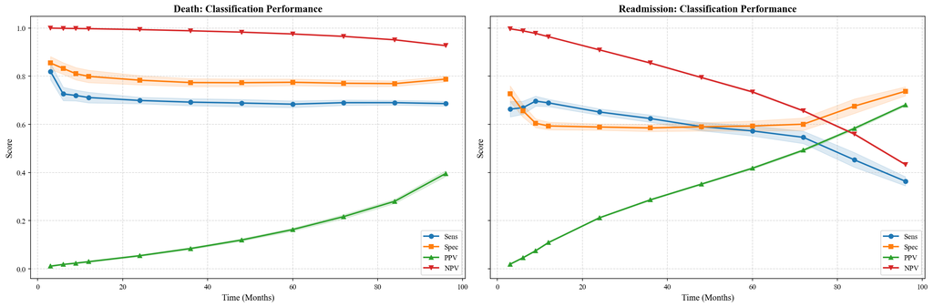

```
================================================================================
📈 PLOT: Discrimination (Uno's C-Index)
================================================================================

================================================================================
📉 PLOT: Time-Dependent Integrated Brier Score (IBS)
================================================================================
💾 Saved plot: XGB7_comb_IBS_CI_20260206_1448.png
```

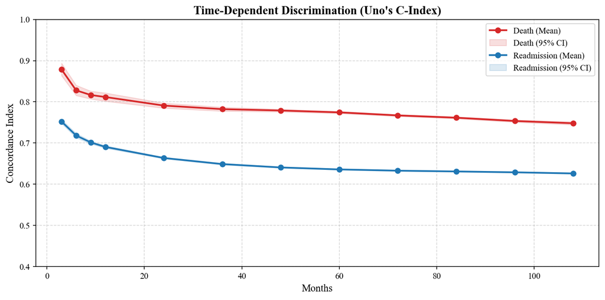

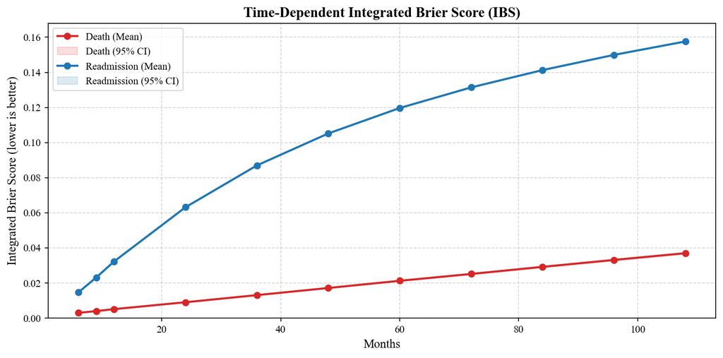

```
💾 Saved plot: XGB7_comb_Uno_CIndex_CI_20260206_1448.png
```

```
================================================================================
📋 TABLES
================================================================================

>>> GLOBAL PERFORMANCE
```

|  | Risk | Metric | Display |
| --- | --- | --- | --- |
| 0 | Death | IBS | 0.037 (0.036-0.037) |
| 1 | Death | Uno's C-Index | 0.751 (0.748-0.755) |
| 2 | Readmission | IBS | 0.158 (0.157-0.158) |
| 3 | Readmission | Uno's C-Index | 0.623 (0.622-0.625) |

```
>>> DETAILED METRICS BY TIME
```

| Risk | Metric Time_num | Brier Score | F1 | IBS | NPV | PPV | Sens | Spec | Uno's C-Index |
| --- | --- | --- | --- | --- | --- | --- | --- | --- | --- |
| Death | 3.0 | 0.002 (0.001-0.002) | 0.022 (0.018-0.026) | NaN | 1.000 (1.000-1.000) | 0.011 (0.009-0.013) | 0.820 (0.786-0.854) | 0.855 (0.828-0.882) | 0.879 (0.863-0.894) |
|  | 6.0 | 0.004 (0.004-0.004) | 0.036 (0.032-0.039) | 0.003 (0.003-0.003) | 0.999 (0.999-0.999) | 0.018 (0.016-0.020) | 0.726 (0.699-0.754) | 0.832 (0.808-0.856) | 0.828 (0.815-0.840) |
|  | 9.0 | 0.006 (0.006-0.006) | 0.046 (0.041-0.050) | 0.004 (0.004-0.004) | 0.998 (0.998-0.998) | 0.024 (0.021-0.026) | 0.720 (0.698-0.742) | 0.810 (0.785-0.836) | 0.817 (0.807-0.826) |
|  | 12.0 | 0.008 (0.008-0.008) | 0.057 (0.051-0.063) | 0.005 (0.005-0.005) | 0.997 (0.997-0.998) | 0.030 (0.027-0.033) | 0.712 (0.689-0.734) | 0.799 (0.774-0.825) | 0.812 (0.802-0.822) |
|  | 24.0 | 0.017 (0.017-0.018) | 0.101 (0.095-0.106) | 0.009 (0.009-0.009) | 0.994 (0.993-0.994) | 0.055 (0.051-0.058) | 0.699 (0.686-0.713) | 0.783 (0.764-0.803) | 0.791 (0.785-0.797) |
|  | 36.0 | 0.028 (0.028-0.029) | 0.150 (0.144-0.156) | 0.013 (0.013-0.013) | 0.989 (0.988-0.989) | 0.084 (0.080-0.089) | 0.692 (0.678-0.707) | 0.774 (0.757-0.790) | 0.782 (0.777-0.787) |
|  | 48.0 | 0.040 (0.040-0.041) | 0.203 (0.196-0.210) | 0.017 (0.017-0.017) | 0.983 (0.982-0.984) | 0.120 (0.115-0.125) | 0.689 (0.673-0.704) | 0.773 (0.757-0.789) | 0.779 (0.776-0.782) |
|  | 60.0 | 0.056 (0.055-0.057) | 0.262 (0.254-0.269) | 0.021 (0.021-0.022) | 0.975 (0.975-0.976) | 0.163 (0.157-0.169) | 0.684 (0.670-0.698) | 0.775 (0.761-0.789) | 0.774 (0.772-0.777) |
|  | 72.0 | 0.078 (0.077-0.079) | 0.328 (0.319-0.337) | 0.025 (0.025-0.026) | 0.965 (0.965-0.966) | 0.217 (0.209-0.225) | 0.690 (0.679-0.701) | 0.771 (0.757-0.784) | 0.767 (0.765-0.769) |
|  | 84.0 | 0.107 (0.105-0.108) | 0.397 (0.389-0.405) | 0.029 (0.029-0.030) | 0.951 (0.950-0.952) | 0.280 (0.272-0.289) | 0.690 (0.680-0.700) | 0.769 (0.758-0.781) | 0.761 (0.759-0.764) |
|  | 96.0 | 0.154 (0.152-0.156) | 0.500 (0.491-0.508) | 0.033 (0.033-0.034) | 0.927 (0.926-0.928) | 0.396 (0.384-0.408) | 0.686 (0.676-0.696) | 0.788 (0.776-0.800) | 0.753 (0.751-0.756) |
|  | 108.0 | 0.220 (0.218-0.222) | 0.585 (0.579-0.592) | 0.037 (0.036-0.037) | 0.889 (0.887-0.891) | 0.519 (0.507-0.532) | 0.676 (0.666-0.686) | 0.802 (0.792-0.813) | 0.748 (0.744-0.752) |
| Readmission | 3.0 | 0.007 (0.007-0.008) | 0.037 (0.034-0.041) | NaN | 0.997 (0.996-0.997) | 0.019 (0.018-0.021) | 0.663 (0.631-0.695) | 0.727 (0.695-0.760) | 0.752 (0.747-0.757) |
|  | 6.0 | 0.023 (0.022-0.023) | 0.085 (0.082-0.089) | 0.015 (0.014-0.015) | 0.988 (0.988-0.989) | 0.046 (0.044-0.048) | 0.669 (0.642-0.697) | 0.657 (0.630-0.683) | 0.718 (0.713-0.723) |
|  | 9.0 | 0.042 (0.041-0.042) | 0.135 (0.132-0.138) | 0.023 (0.023-0.024) | 0.978 (0.977-0.979) | 0.075 (0.073-0.077) | 0.697 (0.676-0.717) | 0.605 (0.587-0.623) | 0.701 (0.698-0.705) |
|  | 12.0 | 0.062 (0.061-0.062) | 0.188 (0.185-0.191) | 0.032 (0.032-0.033) | 0.964 (0.963-0.965) | 0.109 (0.107-0.111) | 0.689 (0.674-0.705) | 0.593 (0.577-0.609) | 0.691 (0.687-0.694) |
|  | 24.0 | 0.122 (0.121-0.122) | 0.319 (0.317-0.321) | 0.063 (0.063-0.064) | 0.909 (0.908-0.911) | 0.212 (0.210-0.214) | 0.651 (0.638-0.665) | 0.589 (0.576-0.602) | 0.664 (0.662-0.665) |
|  | 36.0 | 0.164 (0.164-0.164) | 0.392 (0.390-0.394) | 0.087 (0.087-0.087) | 0.855 (0.853-0.857) | 0.287 (0.284-0.290) | 0.624 (0.609-0.639) | 0.585 (0.570-0.600) | 0.649 (0.647-0.651) |
|  | 48.0 | 0.199 (0.199-0.199) | 0.439 (0.436-0.442) | 0.105 (0.105-0.106) | 0.795 (0.792-0.797) | 0.352 (0.349-0.355) | 0.591 (0.573-0.608) | 0.590 (0.573-0.607) | 0.641 (0.639-0.642) |
|  | 60.0 | 0.230 (0.229-0.230) | 0.480 (0.475-0.485) | 0.120 (0.119-0.120) | 0.735 (0.732-0.738) | 0.418 (0.414-0.422) | 0.573 (0.552-0.594) | 0.593 (0.572-0.614) | 0.636 (0.635-0.637) |
|  | 72.0 | 0.263 (0.262-0.264) | 0.513 (0.503-0.523) | 0.131 (0.131-0.132) | 0.656 (0.653-0.659) | 0.493 (0.488-0.498) | 0.546 (0.520-0.572) | 0.601 (0.575-0.627) | 0.633 (0.632-0.634) |
|  | 84.0 | 0.296 (0.295-0.297) | 0.501 (0.484-0.517) | 0.141 (0.141-0.142) | 0.560 (0.556-0.563) | 0.583 (0.577-0.589) | 0.453 (0.422-0.483) | 0.676 (0.646-0.706) | 0.631 (0.630-0.632) |
|  | 96.0 | 0.337 (0.335-0.338) | 0.470 (0.455-0.484) | 0.150 (0.150-0.150) | 0.433 (0.431-0.436) | 0.681 (0.676-0.686) | 0.364 (0.345-0.383) | 0.738 (0.719-0.756) | 0.629 (0.628-0.630) |
|  | 108.0 | 0.367 (0.365-0.368) | 0.477 (0.458-0.495) | 0.158 (0.157-0.158) | 0.328 (0.325-0.330) | 0.773 (0.766-0.779) | 0.350 (0.330-0.371) | 0.751 (0.730-0.772) | 0.626 (0.625-0.627) |

```python
#@title 📊 Step 7: Final Reporting & Plots (XGB7 Readm Corr - Local/Positron Version)

import matplotlib.pyplot as plt
import seaborn as sns
import pandas as pd
import numpy as np
import matplotlib as mpl
from datetime import datetime
from IPython.display import display # Standard for Positron/Jupyter

# --- 1. CONFIGURATION ---
# Font Settings: Times New Roman (standard scientific publishing style)
mpl.rcParams.update({
    "font.family": "serif",
    "font.serif": ["Times New Roman", "Times", "Nimbus Roman", "DejaVu Serif"],
    "pdf.fonttype": 42,
    "ps.fonttype": 42,
    "axes.labelsize": 12,
    "axes.titlesize": 14,
    "xtick.labelsize": 10,
    "ytick.labelsize": 10,
    "figure.dpi": 150
})

timestamp = datetime.now().strftime("%Y%m%d_%H%M")

# --- 2. ROBUST DATA LOADING ---
try:
    if 'metrics_log_comb' not in locals():
        raise NameError("metrics_log_comb not found in memory.")

    # Check if it is already a DataFrame
    if isinstance(metrics_log_comb, pd.DataFrame):
        print("✅ metrics_log_comb is already a DataFrame. Using directly.")
        df_res = metrics_log_comb.copy()
    elif isinstance(metrics_log_comb, dict):
        print("✅ metrics_log_comb is a dictionary. Converting to DataFrame...")
        df_res = pd.DataFrame(metrics_log_comb['data'], columns=metrics_log_comb['columns'])
    else:
        raise TypeError(f"Unexpected type for metrics_log_comb: {type(metrics_log_comb)}")

    print(f"📊 Data loaded: {len(df_res)} rows.")

except NameError:
    print("❌ Error: 'metrics_log_comb' variable not found in memory.")
    raise

# --- 3. AGGREGATE STATS (Mean, Std, SE, CI) ---
# Group by Risk, Metric, and Time
df_agg = df_res.groupby(['Risk', 'Metric', 'Time'])['Value'].agg(['mean', 'std', 'count']).reset_index()

# Ensure numeric time column exists for plotting
df_agg['Time_num'] = pd.to_numeric(df_agg['Time'], errors='coerce')

# Calculate Standard Error and 95% CI
df_agg['se'] = df_agg['std'].fillna(0) / np.sqrt(df_agg['count'])
df_agg['lower'] = df_agg['mean'] - 1.96 * df_agg['se']
df_agg['upper'] = df_agg['mean'] + 1.96 * df_agg['se']

# Create "Display" column: "Mean (Lower-Upper)"
df_agg['Display'] = df_agg.apply(
    lambda x: f"{x['mean']:.3f} ({x['lower']:.3f}-{x['upper']:.3f})", axis=1
)

# Save Summary CSV locally
summary_filename = f"XGB7_comb_final_summary_{timestamp}.csv"
df_agg.to_csv(summary_filename, index=False)
print(f"💾 Saved summary stats to local directory: {summary_filename}")

# --- 4. PLOT 1: CLASSIFICATION METRICS ---
print("\n" + "="*80)
print("📈 PLOT: Classification Metrics")
print("="*80)

fig, axes = plt.subplots(1, 2, figsize=(18, 6), sharey=True)
colors = {'Sens': '#1f77b4', 'Spec': '#ff7f0e', 'PPV': '#2ca02c', 'NPV': '#d62728'}
markers = {'Sens': 'o', 'Spec': 's', 'PPV': '^', 'NPV': 'v'}

for i, risk in enumerate(['Death', 'Readmission']):
    ax = axes[i]
    # Filter: Risk, Time <= 96 (numeric), and Specific Metrics
    subset = df_agg[
        (df_agg['Risk'] == risk) &
        (df_agg['Time_num'] <= 96) &
        (df_agg['Metric'].isin(colors.keys()))
    ]

    for m in colors.keys():
        d = subset[subset['Metric'] == m]
        if not d.empty:
            ax.plot(d['Time_num'], d['mean'], label=m, color=colors[m], marker=markers[m], linewidth=2)
            ax.fill_between(d['Time_num'], d['lower'], d['upper'], color=colors[m], alpha=0.15)

    ax.set_title(f"{risk}: Classification Performance", fontsize=14, fontweight='bold')
    ax.set_xlabel("Time (Months)")
    ax.set_ylabel("Score")
    ax.legend(loc='lower right')
    ax.grid(True, linestyle='--', alpha=0.5)

plt.tight_layout()

# Save locally
fname_cls = f"XGB7_comb_Classification_Metrics_{timestamp}"
plt.savefig(f"{fname_cls}.pdf", bbox_inches="tight")
plt.savefig(f"{fname_cls}.png", dpi=500, bbox_inches="tight")
print(f"💾 Saved plot: {fname_cls}.png")

plt.show()

# --- 5. PLOT 2: UNO'S C-INDEX ---
print("\n" + "="*80)
print("📈 PLOT: Discrimination (Uno's C-Index)")
print("="*80)

plt.figure(figsize=(10, 5))
uno_df = df_agg[df_agg['Metric'] == "Uno's C-Index"].copy()
uno_df['Time_num'] = pd.to_numeric(uno_df['Time'], errors='coerce')

risk_colors = {'Death': '#D62728', 'Readmission': '#1F77B4'}

for risk in ['Death', 'Readmission']:
    d = uno_df[uno_df['Risk'] == risk]
    if not d.empty:
        # Sort by time to ensure lines connect correctly
        d = d.sort_values('Time_num')
        # Filter out NaN times (global scores) for the line plot
        d_plot = d.dropna(subset=['Time_num'])

        plt.plot(d_plot['Time_num'], d_plot['mean'], marker='o', label=f"{risk} (Mean)", color=risk_colors[risk], linewidth=2)
        plt.fill_between(d_plot['Time_num'], d_plot['lower'], d_plot['upper'], color=risk_colors[risk], alpha=0.15, label=f"{risk} (95% CI)")

plt.title("Time-Dependent Discrimination (Uno's C-Index)", fontsize=14, fontweight='bold')
plt.xlabel("Months")
plt.ylabel("Concordance Index")
plt.ylim(0.4, 1.0)
plt.legend()
plt.grid(True, linestyle='--', alpha=0.5)
plt.tight_layout()

# --- PLOT: Integrated Brier Score (IBS) ---
print("\n" + "="*80)
print("📉 PLOT: Time-Dependent Integrated Brier Score (IBS)")
print("="*80)

plt.figure(figsize=(10, 5))
ibs_df = df_agg[df_agg['Metric'] == 'IBS'].copy()
ibs_df['Time_num'] = pd.to_numeric(ibs_df['Time'], errors='coerce')

risk_colors = {'Death': '#D62728', 'Readmission': '#1F77B4'}

for risk in ['Death', 'Readmission']:
    d = ibs_df[ibs_df['Risk'] == risk]
    if not d.empty:
        # Sort by time to ensure lines connect correctly
        d = d.sort_values('Time_num')
        # Filter out NaN times (global IBS) for the line plot
        d_plot = d.dropna(subset=['Time_num'])

        plt.plot(d_plot['Time_num'], d_plot['mean'], marker='o', label=f"{risk} (Mean)", color=risk_colors[risk], linewidth=2)
        plt.fill_between(d_plot['Time_num'], d_plot['lower'], d_plot['upper'], color=risk_colors[risk], alpha=0.15, label=f"{risk} (95% CI)")

plt.title("Time-Dependent Integrated Brier Score (IBS)", fontsize=14, fontweight='bold')
plt.xlabel("Months")
plt.ylabel("Integrated Brier Score (lower is better)")
# set sensible y-limits: ensure lower bound >= 0
ymin = max(0.0, ibs_df['lower'].min() - 0.01) if not ibs_df.empty else 0.0
ymax = ibs_df['upper'].max() + 0.01 if not ibs_df.empty else 1.0
plt.ylim(ymin, ymax)
plt.legend()
plt.grid(True, linestyle='--', alpha=0.5)
plt.tight_layout()

# Save locally
fname_ibs = f"XGB7_comb_IBS_CI_{timestamp}"
plt.savefig(f"{fname_ibs}.pdf", bbox_inches="tight")
plt.savefig(f"{fname_ibs}.png", dpi=500, bbox_inches="tight")
print(f"💾 Saved plot: {fname_ibs}.png")

plt.show()

# Save locally
fname_uno = f"XGB7_comb_Uno_CIndex_CI_{timestamp}"
plt.savefig(f"{fname_uno}.pdf", bbox_inches="tight")
plt.savefig(f"{fname_uno}.png", dpi=500, bbox_inches="tight")
print(f"💾 Saved plot: {fname_uno}.png")

plt.show()

# --- 6. TABLES ---
print("\n" + "="*80)
print("📋 TABLES")
print("="*80)

# Table A: Global Scores
print("\n>>> GLOBAL PERFORMANCE")
# Check for 'Global' in Time or specific metrics usually associated with global
global_df = df_agg[df_agg['Time'] == 'Global'][['Risk', 'Metric', 'Display']].reset_index(drop=True)
if not global_df.empty:
    display(global_df)
else:
    print("No global metrics found in aggregation.")

# Table B: Detailed Time-Dependent Metrics
print("\n>>> DETAILED METRICS BY TIME")
pivot_df = df_agg.pivot_table(index=['Risk', 'Time_num'], columns='Metric', values='Display', aggfunc='first')
display(pivot_df)
```

For death, sensitivity decreases as time since discharge progresses (some deaths are misclassified), but specificity remains high and stable (few false positives). An NPV close to 1 is expected given that the event is highly infrequent. Regarding PPV, as time progresses, it becomes easier to predict deaths.

In contrast, readmission becomes increasingly difficult to predict over time. Specificity is moderate but improves as time goes by, while ruling out readmission becomes less reliable at longer horizons. However, late readmissions, when predicted, tend to be more reliable.

In terms of discrimination, it is easier to rank patients death risks even in the long term. However, for readmission, discrimination capacity decrease

Earlier AUC estimates were derived from a binary classification framing and are not directly comparable to the cause-specific, time-dependent AUC reported here.

## SHAP

```
📂 Loading SHAP Data from: xgb6_DUAL_SHAP_Aggregated_20260206_1448.pkl
   ✅ Found DUAL Data. Extracting READMISSION SHAP.
   ✅ Patients: 88504
   ✅ SHAP Shape: (88504, 56)

⚡ Creating SHAP Explanation Object...

📊 Generating Global Bar Plot...
   💾 Saved: XGB8_Readm_DUAL_SHAP_Bar_20260206_1451.png
```

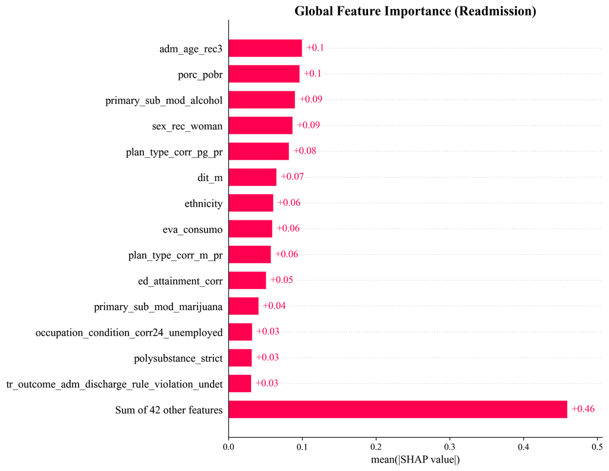

```
🐝 Generating Beeswarm Plot...
   💾 Saved: XGB8_Readm_DUAL_SHAP_Beeswarm_20260206_1451.png
```

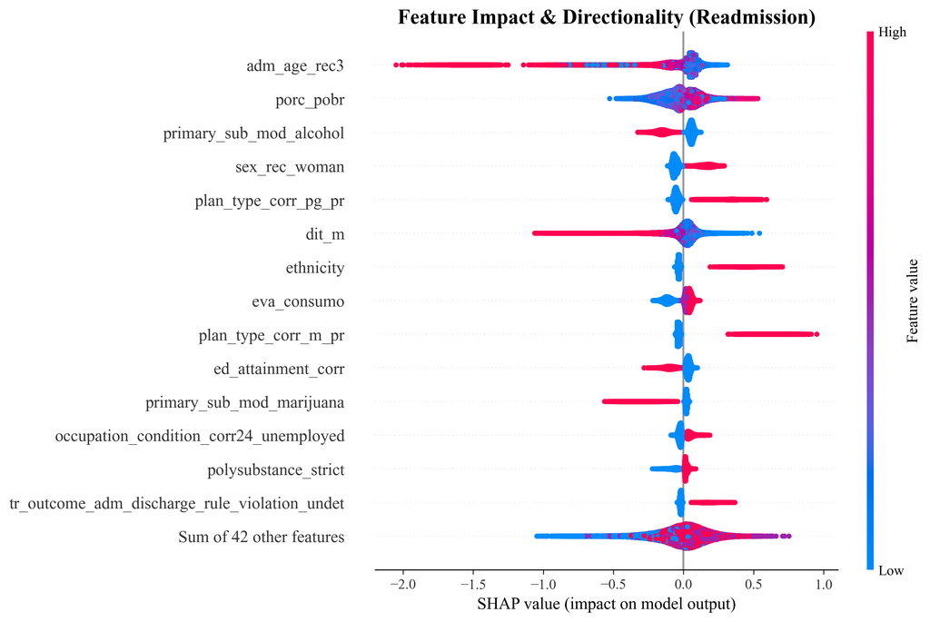

```
💧 Generating Waterfall Plots...
   💾 Saved: XGB8_Readm_DUAL_SHAP_Waterfall_HighestRisk_20260206_1451.png
```

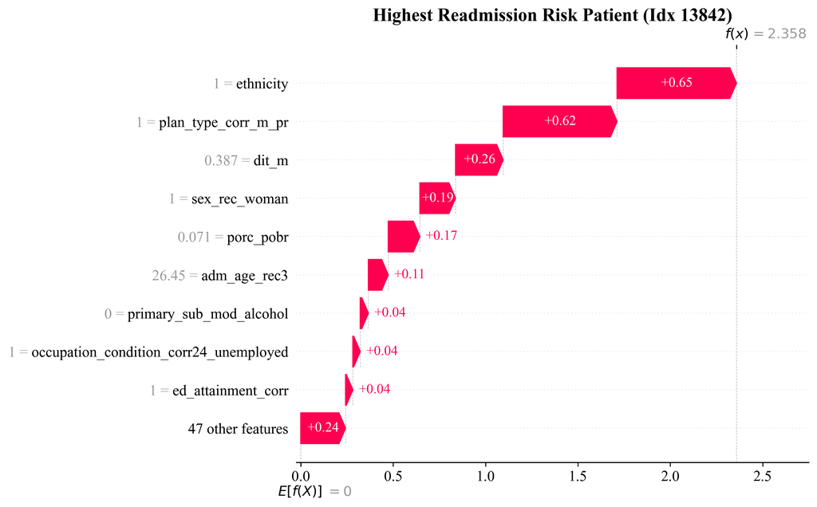

```
   💾 Saved: XGB8_Readm_DUAL_SHAP_Waterfall_LowestRisk_20260206_1451.png
```

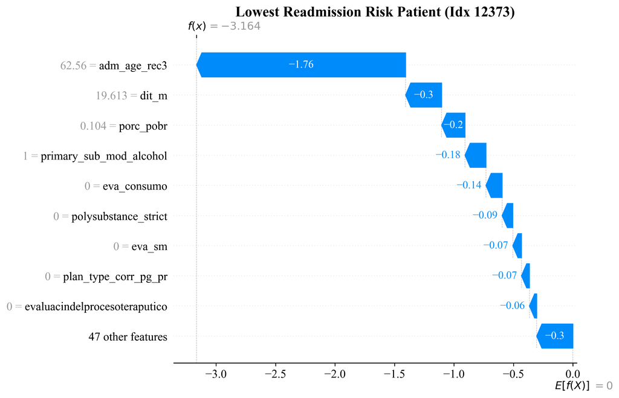

```
🏁 SHAP Analysis Complete.
```

```python
#@title 🔍 Step 8: SHAP Analysis & Plots (Readmission from DUAL Data)

import shap
import pickle
import numpy as np
import pandas as pd
import glob
import matplotlib.pyplot as plt
import matplotlib as mpl
from datetime import datetime

# --- 1. CONFIGURATION ---
mpl.rcParams.update({
    "font.family": "serif",
    "font.serif": ["Times New Roman", "Times", "Nimbus Roman", "DejaVu Serif"],
    "pdf.fonttype": 42,
    "ps.fonttype": 42,
    "axes.labelsize": 14,
    "axes.titlesize": 16,
    "xtick.labelsize": 12,
    "ytick.labelsize": 12,
    "figure.dpi": 300
})

timestamp = datetime.now().strftime("%Y%m%d_%H%M")

# --- 2. LOAD DATA ---
try:
    # 1. Search for DUAL SHAP file (Preferred)
    shap_files = sorted(glob.glob("xgb6_DUAL_SHAP_Aggregated_*.pkl"))

    if not shap_files:
        # 2. Fallback to old CV-SHAP file
        print("⚠️ DUAL file not found. Searching for generic CV-SHAP...")
        shap_files = sorted(glob.glob("xgb6_cvshap_SHAP_Aggregated_*.pkl"))

    if not shap_files:
        raise FileNotFoundError("❌ No SHAP file found! Please run Step 5 (Dual Analysis) first.")

    shap_file = shap_files[-1]
    print(f"📂 Loading SHAP Data from: {shap_file}")

    with open(shap_file, 'rb') as f:
        shap_data = pickle.load(f)

    # Extract Data (Handling Dual Structure)
    if 'shap_r_all' in shap_data:
        print("   ✅ Found DUAL Data. Extracting READMISSION SHAP.")
        X_all = shap_data['X_all']
        shap_all = shap_data['shap_r_all'] # <--- Target Readmission
        feature_names = shap_data['feature_names']
    elif 'shap_all' in shap_data:
        print("   ⚠️ Found Single/Generic Data. Using available SHAP.")
        X_all = shap_data['X_all']
        shap_all = shap_data['shap_all']
        feature_names = shap_data['feature_names']
    else:
        raise ValueError("❌ SHAP file structure unrecognized.")

    print(f"   ✅ Patients: {X_all.shape[0]}")
    print(f"   ✅ SHAP Shape: {shap_all.shape}")

except Exception as e:
    print(f"❌ Error loading data: {e}")
    raise

# --- 3. CREATE EXPLANATION OBJECT ---
print("\n⚡ Creating SHAP Explanation Object...")

# FIX: Ensure base_values is an ARRAY matching data length
# This fixes the "TypeError: float() argument... not NoneType" in waterfall plots
try:
    # We assume centered data for CV-SHAP (Base value ~ 0 in log-odds space)
    base_val_scalar = 0.0
    base_values_array = np.full(X_all.shape[0], base_val_scalar)
except:
    base_values_array = np.zeros(X_all.shape[0])

explanation = shap.Explanation(
    values=shap_all,
    data=X_all.values,
    feature_names=feature_names,
    base_values=base_values_array # <--- Critical for Waterfall
)

# --- 4. PLOTTING FUNCTION ---
def save_plot(fig, name):
    fname = f"XGB8_Readm_DUAL_SHAP_{name}_{timestamp}"
    if fig is None: fig = plt.gcf()
    fig.savefig(f"{fname}.pdf", bbox_inches='tight')
    fig.savefig(f"{fname}.png", dpi=300, bbox_inches='tight')
    print(f"   💾 Saved: {fname}.png")

# --- 5. GENERATE PLOTS ---

# A. Global Bar Plot
print("\n📊 Generating Global Bar Plot...")
plt.figure(figsize=(10, 8))
shap.plots.bar(explanation, max_display=15, show=False)
plt.title("Global Feature Importance (Readmission)", fontsize=16, fontweight='bold')
save_plot(plt.gcf(), "Bar")
plt.show()

# B. Beeswarm Plot
print("\n🐝 Generating Beeswarm Plot...")
plt.figure(figsize=(12, 8))
shap.plots.beeswarm(explanation, max_display=15, show=False)
plt.title("Feature Impact & Directionality (Readmission)", fontsize=16, fontweight='bold')
save_plot(plt.gcf(), "Beeswarm")
plt.show()

# C. Waterfall Plots (Extreme Cases)
print("\n💧 Generating Waterfall Plots...")

# Case 1: Highest Risk
max_idx = np.argmax(explanation.values.sum(axis=1))
plt.figure(figsize=(10, 8))
shap.plots.waterfall(explanation[max_idx], max_display=10, show=False)
plt.title(f"Highest Readmission Risk Patient (Idx {max_idx})", fontsize=16, fontweight='bold')
save_plot(plt.gcf(), "Waterfall_HighestRisk")
plt.show()

# Case 2: Lowest Risk
min_idx = np.argmin(explanation.values.sum(axis=1))
plt.figure(figsize=(10, 8))
shap.plots.waterfall(explanation[min_idx], max_display=10, show=False)
plt.title(f"Lowest Readmission Risk Patient (Idx {min_idx})", fontsize=16, fontweight='bold')
save_plot(plt.gcf(), "Waterfall_LowestRisk")
plt.show()

print("\n🏁 SHAP Analysis Complete.")
```

```
📂 Loading SHAP Data from: xgb6_DUAL_SHAP_Aggregated_20260206_1448.pkl
   ✅ Found Death (Mortality) SHAP values.
   ✅ Patients: 88504
   ✅ SHAP Shape: (88504, 56)

⚡ Creating SHAP Explanation Object (Mortality)...

📊 Generating Global Bar Plot...
   💾 Saved: XGB8_Death_DUAL_SHAP_Bar_20260206_1456.png
```

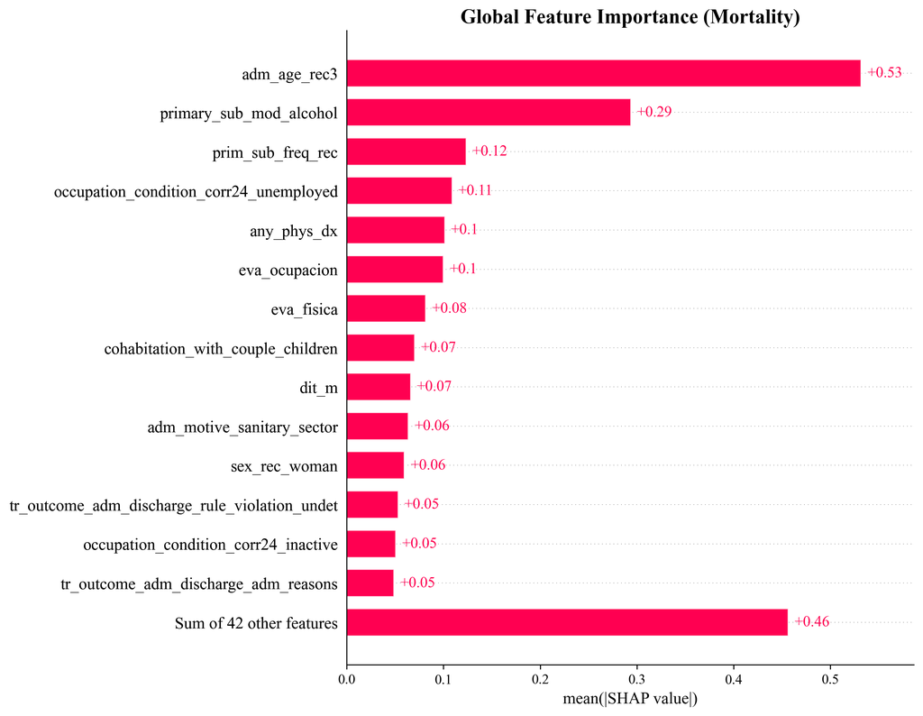

```
🐝 Generating Beeswarm Plot...
   💾 Saved: XGB8_Death_DUAL_SHAP_Beeswarm_20260206_1456.png
```

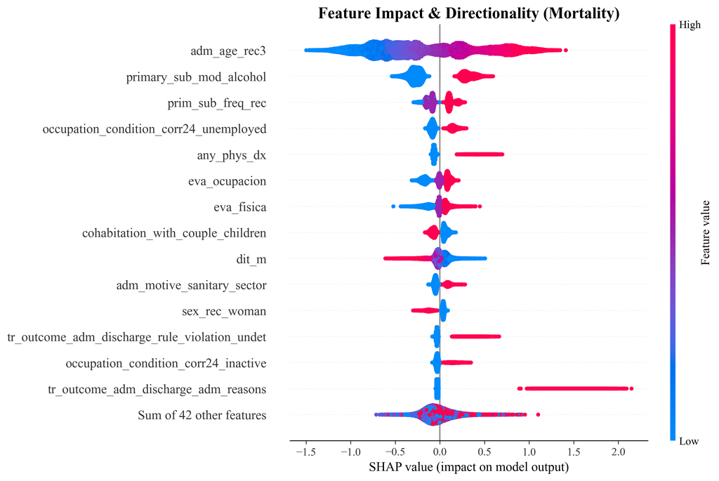

```
💧 Generating Waterfall Plots...
   💾 Saved: XGB8_Death_DUAL_SHAP_Waterfall_HighestRisk_20260206_1456.png
```

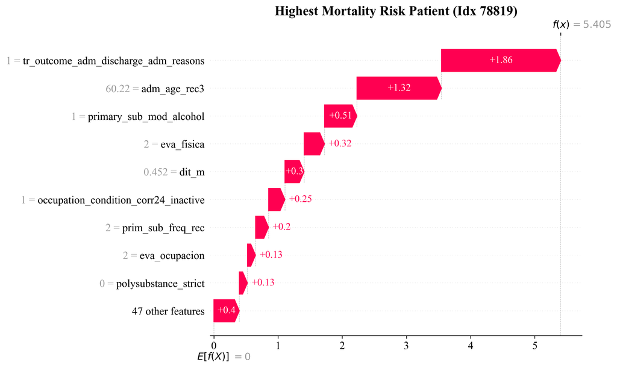

```
   💾 Saved: XGB8_Death_DUAL_SHAP_Waterfall_LowestRisk_20260206_1456.png
```

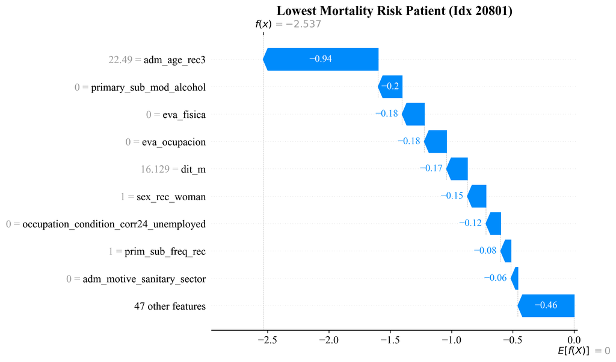

```
🏁 Mortality SHAP Analysis Complete.
```

```python
#@title 💀 Step 8b: SHAP Analysis & Plots (Death / Mortality - DUAL)

import shap
import pickle
import numpy as np
import pandas as pd
import glob
import matplotlib.pyplot as plt
import matplotlib as mpl
from datetime import datetime

# --- 1. CONFIGURATION ---
mpl.rcParams.update({
    "font.family": "serif",
    "font.serif": ["Times New Roman", "Times", "Nimbus Roman", "DejaVu Serif"],
    "pdf.fonttype": 42,
    "ps.fonttype": 42,
    "axes.labelsize": 14,
    "axes.titlesize": 16,
    "xtick.labelsize": 12,
    "ytick.labelsize": 12,
    "figure.dpi": 300
})

timestamp = datetime.now().strftime("%Y%m%d_%H%M")

# --- 2. LOAD DATA ---
try:
    # 1. Search for the DUAL file first (contains both Readmission and Death)
    shap_files = sorted(glob.glob("xgb6_DUAL_SHAP_Aggregated_*.pkl"))

    if not shap_files:
        raise FileNotFoundError("❌ No DUAL SHAP file found! Please run the 'Step 5: Dual CV-SHAP' Analysis step.")

    shap_file = shap_files[-1]
    print(f"📂 Loading SHAP Data from: {shap_file}")

    with open(shap_file, 'rb') as f:
        shap_data = pickle.load(f)

    # Check for Death data
    if 'shap_d_all' in shap_data:
        shap_all = shap_data['shap_d_all'] # <--- LOAD DEATH VALUES
        print("   ✅ Found Death (Mortality) SHAP values.")
    else:
        raise ValueError("❌ This file does not contain Death SHAP values.")

    X_all = shap_data['X_all']
    feature_names = shap_data['feature_names']

    print(f"   ✅ Patients: {X_all.shape[0]}")
    print(f"   ✅ SHAP Shape: {shap_all.shape}")

except Exception as e:
    print(f"❌ Error: {e}")
    raise

# --- 3. CREATE EXPLANATION OBJECT ---
print("\n⚡ Creating SHAP Explanation Object (Mortality)...")

# FIX: Ensure base_values is an ARRAY matching data length
# This fixes the "TypeError: float() argument... not NoneType" in waterfall plots
try:
    # We assume centered data for CV-SHAP (Base value ~ 0 in log-odds space)
    base_val_scalar = 0.0
    base_values_array = np.full(X_all.shape[0], base_val_scalar)
except:
    base_values_array = np.zeros(X_all.shape[0])

explanation = shap.Explanation(
    values=shap_all,
    data=X_all.values,
    feature_names=feature_names,
    base_values=base_values_array
)

# --- 4. PLOTTING FUNCTION ---
def save_plot(fig, name):
    fname = f"XGB8_Death_DUAL_SHAP_{name}_{timestamp}"
    if fig is None: fig = plt.gcf()
    fig.savefig(f"{fname}.pdf", bbox_inches='tight')
    fig.savefig(f"{fname}.png", dpi=300, bbox_inches='tight')
    print(f"   💾 Saved: {fname}.png")

    # Fail-safe download
    try:
        from google.colab import files
        files.download(f"{fname}.pdf")
        files.download(f"{fname}.png")
    except:
        pass

# --- 5. GENERATE PLOTS ---

# A. Global Bar Plot
print("\n📊 Generating Global Bar Plot...")
plt.figure(figsize=(10, 8))
shap.plots.bar(explanation, max_display=15, show=False)
plt.title("Global Feature Importance (Mortality)", fontsize=16, fontweight='bold')
save_plot(plt.gcf(), "Bar")
plt.show()

# B. Beeswarm Plot
print("\n🐝 Generating Beeswarm Plot...")
plt.figure(figsize=(12, 8))
shap.plots.beeswarm(explanation, max_display=15, show=False)
plt.title("Feature Impact & Directionality (Mortality)", fontsize=16, fontweight='bold')
save_plot(plt.gcf(), "Beeswarm")
plt.show()

# C. Waterfall Plots (Extreme Cases)
print("\n💧 Generating Waterfall Plots...")

# Case 1: Highest Risk of Death
max_idx = np.argmax(explanation.values.sum(axis=1))
plt.figure(figsize=(10, 8))
shap.plots.waterfall(explanation[max_idx], max_display=10, show=False)
plt.title(f"Highest Mortality Risk Patient (Idx {max_idx})", fontsize=16, fontweight='bold')
save_plot(plt.gcf(), "Waterfall_HighestRisk")
plt.show()

# Case 2: Lowest Risk of Death
min_idx = np.argmin(explanation.values.sum(axis=1))
plt.figure(figsize=(10, 8))
shap.plots.waterfall(explanation[min_idx], max_display=10, show=False)
plt.title(f"Lowest Mortality Risk Patient (Idx {min_idx})", fontsize=16, fontweight='bold')
save_plot(plt.gcf(), "Waterfall_LowestRisk")
plt.show()

print("\n🏁 Mortality SHAP Analysis Complete.")
```

```python
#@title 📊 Step 9: Export Detailed Predictor Analysis (XGBoost - DUAL SHAP)

import pandas as pd
import numpy as np
import shap
import xgboost as xgb
import pickle
import glob
from scipy.stats import pearsonr
from datetime import datetime
import matplotlib.pyplot as plt

# --- 1. CONFIGURATION ---
timestamp = datetime.now().strftime("%Y%m%d_%H%M")
excel_filename = f"XGB9_Predictor_Analysis_DUAL_{timestamp}.xlsx"

# --- 2. HELPER FUNCTIONS ---

def get_direction_and_robustness(feature_values, shap_values):
    """
    Determines if a feature is a Risk Factor vs Protective based on correlation.
    """
    # 1. Robustness: Std Dev of the absolute impact
    robustness = np.std(np.abs(shap_values))

    # 2. Direction: Correlation between Feature Value and SHAP Value
    try:
        # Handle constant features
        if np.std(feature_values) < 1e-6:
            return "Neutral (Constant)", 0.0, 0.0

        corr, _ = pearsonr(feature_values, shap_values)

        if corr > 0.1: direction = "Risk Factor (↑)"
        elif corr < -0.1: direction = "Protective (↓)"
        else: direction = "Mixed/Non-Linear"

        return direction, corr, robustness
    except:
        return "Unknown", 0.0, robustness

def analyze_risk_factors_from_shap(X_data, shap_vals, feature_names, risk_name):
    """
    Generates the top 25 predictor table using pre-calculated SHAP values.
    """
    print(f"⚡ Analyzing top predictors for: {risk_name}...")

    # B. Compile Metrics
    feature_data = []

    for i, fname in enumerate(feature_names):
        # Extract columns
        if isinstance(X_data, pd.DataFrame):
            f_values = X_data.iloc[:, i].values
        else:
            f_values = X_data[:, i]

        s_values = shap_vals[:, i]

        # 1. Global Importance (Mean |SHAP|)
        importance = np.mean(np.abs(s_values))

        # 2. Direction & Robustness
        direction, corr, robust_score = get_direction_and_robustness(f_values, s_values)

        feature_data.append({
            'Rank': 0, # Placeholder
            'Feature': fname,
            'Importance (Mean |SHAP|)': importance,
            'Direction': direction,
            'Type': 'Risk' if 'Risk' in direction else 'Protective' if 'Protective' in direction else 'Complex',
            'Robustness (SD of Impact)': robust_score,
            'Correlation (Value vs Risk)': corr
        })

    # C. Create DataFrame & Sort
    df = pd.DataFrame(feature_data)
    df = df.sort_values(by='Importance (Mean |SHAP|)', ascending=False).reset_index(drop=True)
    df['Rank'] = df.index + 1

    return df.head(50) # Return Top 50

# --- 3. MAIN EXECUTION ---

try:
    # ---------------------------------------------------------
    # A. LOAD DUAL SHAP DATA
    # ---------------------------------------------------------
    print("\n📂 Loading DUAL SHAP Data...")

    # 1. Search for DUAL SHAP file
    shap_files = sorted(glob.glob("xgb6_DUAL_SHAP_Aggregated_*.pkl"))

    if not shap_files:
        # Fallback to old name if necessary
        shap_files = sorted(glob.glob("xgb6_cvshap_SHAP_Aggregated_*.pkl"))

    if not shap_files:
        raise FileNotFoundError("❌ No Aggregated SHAP file found! Please run Step 5 (Dual Analysis) first.")

    shap_file = shap_files[-1]
    print(f"   Using: {shap_file}")

    with open(shap_file, 'rb') as f:
        shap_data = pickle.load(f)

    # Validate Keys
    if 'shap_r_all' not in shap_data or 'shap_d_all' not in shap_data:
        raise ValueError("❌ Pickle file does not contain DUAL SHAP data (shap_r_all, shap_d_all).")

    # Extract Data
    X_all = shap_data['X_all']
    shap_r = shap_data['shap_r_all']
    shap_d = shap_data['shap_d_all']
    feature_names = shap_data['feature_names']

    print(f"   ✅ Data Loaded: {X_all.shape[0]} patients")

    # ---------------------------------------------------------
    # B. ANALYZE PREDICTORS
    # ---------------------------------------------------------

    # 1. Readmission
    df_readm = analyze_risk_factors_from_shap(X_all, shap_r, feature_names, "Readmission")

    # 2. Mortality
    df_death = analyze_risk_factors_from_shap(X_all, shap_d, feature_names, "Mortality")

    # ---------------------------------------------------------
    # C. EXPORT TO EXCEL
    # ---------------------------------------------------------
    print(f"\n💾 Saving to Excel: {excel_filename}...")

    with pd.ExcelWriter(excel_filename, engine='xlsxwriter') as writer:
        # Sheet 1: Readmission
        df_readm.to_excel(writer, sheet_name='Readm Predictors', index=False)

        # Sheet 2: Death
        df_death.to_excel(writer, sheet_name='Death Predictors', index=False)

        # Sheet 3: Definitions
        meta_data = pd.DataFrame([
            {'Metric': 'Importance', 'Definition': 'Mean absolute SHAP value from 10-Fold CV. Represents the average magnitude of impact on the model output (Log-Risk).'},
            {'Metric': 'Direction', 'Definition': 'Determined by correlation between feature value and SHAP value. "Risk Factor" means higher values increase risk. "Protective" means higher values decrease risk.'},
            {'Metric': 'Robustness (SD)', 'Definition': 'Standard Deviation of the |SHAP| values. Low SD = Consistent impact across all patients. High SD = Impact depends heavily on context (interactions).'},
            {'Metric': 'Correlation', 'Definition': 'Pearson correlation between the raw feature value and its SHAP value.'}
        ])
        meta_data.to_excel(writer, sheet_name='Definitions', index=False)

        # Formatting
        workbook = writer.book
        header_format = workbook.add_format({'bold': True, 'bg_color': '#D3D3D3', 'border': 1})

        for sheet in ['Readm Predictors', 'Death Predictors', 'Definitions']:
            worksheet = writer.sheets[sheet]
            # Set Column Widths
            worksheet.set_column('B:B', 30) # Feature Name Width
            worksheet.set_column('C:G', 15) # Metric Widths
            # Apply Header Format
            for col_num, value in enumerate(df_readm.columns.values):
                worksheet.write(0, col_num, value, header_format)

    print(f"✅ Export complete: {excel_filename}")

    # Auto-Download
    try:
        from google.colab import files
        files.download(excel_filename)
    except:
        pass

except Exception as e:
    print(f"❌ Unexpected Error: {e}")
    import traceback
    traceback.print_exc()
```

```
📂 Loading DUAL SHAP Data...
   Using: xgb6_DUAL_SHAP_Aggregated_20260206_1448.pkl
   ✅ Data Loaded: 88504 patients
⚡ Analyzing top predictors for: Readmission...
⚡ Analyzing top predictors for: Mortality...

💾 Saving to Excel: XGB9_Predictor_Analysis_DUAL_20260206_1458.xlsx...
✅ Export complete: XGB9_Predictor_Analysis_DUAL_20260206_1458.xlsx
```

```python
#@title 📝 Take-Home Message: Predictor Profiles by Risk (Extended)

import pandas as pd
from IPython.display import display

# --- TAKE-HOME MESSAGE DATAFRAME ---
take_home_msg = pd.DataFrame([
    {
        'Risk Profile': 'Death (Biological & Functional Decline)',
        'Key Predictors (Ranked)': '1. Age (Older)\n2. Primary Substance: Alcohol\n3. High Usage Frequency\n4. Unemployment\n5. Physical Comorbidities',
        'Clinical Interpretation': 'Mortality risk is driven by **biological vulnerability**. The highest risk cohort consists of older males with severe alcohol use disorder, high-frequency consumption patterns, and physical health decline. Unemployment adds a socioeconomic layer, but the core driver is the physical toll of long-term substance use. For this group, the disorder is often terminal rather than cyclical.'
    },
    {
        'Risk Profile': 'Readmission (Socioeconomic & Structural Vulnerability)',
        'Key Predictors (Ranked)': '1. Poverty (Area-Level)\n2. Female Sex\n3. Plan Type (Specific Program Tracks)\n4. Ethnicity (Mapuche)\n5. Polysubstance Use',
        'Clinical Interpretation': 'Readmission is driven by **social instability**. The risk profile shifts entirely from the death model: younger women and ethnic minorities living in high-poverty areas are the most likely to cycle back into treatment. The significance of "Plan Type" and "Poverty" highlights that structural barriers and complex use patterns (polysubstance) make sustained recovery difficult, leading to churn.'
    }
])

# --- DISPLAY ---
print("\n>>> TAKE-HOME MESSAGE: RISK PROFILES")
# Set options to display the full text content
pd.set_option('display.max_colwidth', None)
# Align text to left for better readability if supported, otherwise standard display
display(take_home_msg.style.set_properties(**{'text-align': 'left', 'white-space': 'pre-wrap'}))

#@title 🛡️ Take-Home Message: Protective Factors Analysis (Extended)

# --- PROTECTIVE FACTORS DATAFRAME ---
protective_msg = pd.DataFrame([
    {
        'Outcome': 'Death (Survival Factors)',
        'Top Protective Factors': '1. Female Sex (Biological Resilience)\n2. Treatment Retention (Clinical Dose)\n3. Family/Partner Cohabitation (Social Support)',
        'Clinical Interpretation': '**Social Containment is Key.** Survival is best predicted by having a safety net. Patients who remain in treatment longer (dose-response effect) and live with family or partners have significantly lower mortality risk. This suggests that isolation is a critical mortality accelerant, while social connection serves as a buffer against fatal outcomes.'
    },
    {
        'Outcome': 'Readmission (Stability Factors)',
        'Top Protective Factors': '1. Older Age (Maturation Effect)\n2. Primary Alcohol Use (The "Survivor Paradox")\n3. Treatment Retention',
        'Clinical Interpretation': '**The Survivor Paradox.** Stability against readmission is largely driven by maturation (older age). However, the finding that Alcohol Use protects against readmission is a critical **competing risk artifact**: severe alcohol users have such high mortality rates (as seen in the Death model) that they often do not survive long enough to be readmitted. Thus, "protection" here implies they have exited the system via death, not recovery.'
    }
])

# --- DISPLAY ---
print("\n>>> TAKE-HOME MESSAGE: PROTECTIVE FACTORS")
display(protective_msg.style.set_properties(**{'text-align': 'left', 'white-space': 'pre-wrap'}))
```

```
>>> TAKE-HOME MESSAGE: RISK PROFILES
```

|  | Risk Profile | Key Predictors (Ranked) | Clinical Interpretation |
| --- | --- | --- | --- |
| 0 | Death (Biological & Functional Decline) | 1. Age (Older) 2. Primary Substance: Alcohol 3. High Usage Frequency 4. Unemployment 5. Physical Comorbidities | Mortality risk is driven by **biological vulnerability**. The highest risk cohort consists of older males with severe alcohol use disorder, high-frequency consumption patterns, and physical health dec… |
| 1 | Readmission (Socioeconomic & Structural Vulnerability) | 1. Poverty (Area-Level) 2. Female Sex 3. Plan Type (Specific Program Tracks) 4. Ethnicity (Mapuche) 5. Polysubstance Use | Readmission is driven by **social instability**. The risk profile shifts entirely from the death model: younger women and ethnic minorities living in high-poverty areas are the most likely to cycle ba… |

```
>>> TAKE-HOME MESSAGE: PROTECTIVE FACTORS
```

|  | Outcome | Top Protective Factors | Clinical Interpretation |
| --- | --- | --- | --- |
| 0 | Death (Survival Factors) | 1. Female Sex (Biological Resilience) 2. Treatment Retention (Clinical Dose) 3. Family/Partner Cohabitation (Social Support) | **Social Containment is Key.** Survival is best predicted by having a safety net. Patients who remain in treatment longer (dose-response effect) and live with family or partners have significantly low… |
| 1 | Readmission (Stability Factors) | 1. Older Age (Maturation Effect) 2. Primary Alcohol Use (The "Survivor Paradox") 3. Treatment Retention | **The Survivor Paradox.** Stability against readmission is largely driven by maturation (older age). However, the finding that Alcohol Use protects against readmission is a critical **competing risk a… |

### Interactions

Unlike DeepHit (which creates different risk functions over time), your XGBoost Cox models are time-invariant (Proportional Hazards). This means the model's structure—and its interactions—are constant across all time horizons. Therefore, we do not need to loop through 3, 6, 12 months. We run the discovery once per outcome to find the "Global Interactions" inherent in the model structure.

```python
#@title ⚡ Step 11: Automated Interaction Discovery (XGBoost - DUAL SHAP)

import shap
import pickle
import numpy as np
import pandas as pd
import glob
from scipy.stats import pearsonr
from datetime import datetime

# --- 1. CONFIGURATION ---
TOP_N_FEATURES = 20  # Check interactions for the top 20 main predictors
timestamp = datetime.now().strftime("%Y%m%d_%H%M")
excel_filename = f"XGB11_Robust_Interactions_Dual_CoxPH_{timestamp}.xlsx"

# --- 2. LOAD DUAL SHAP DATA ---
try:
    print("🔄 Loading DUAL SHAP Data...")
    shap_files = sorted(glob.glob("xgb6_DUAL_SHAP_Aggregated_*.pkl"))

    if not shap_files:
        # Fallback to CV-SHAP
        shap_files = sorted(glob.glob("xgb6_cvshap_SHAP_Aggregated_*.pkl"))

    if not shap_files:
        raise FileNotFoundError("❌ No Aggregated SHAP file found! Please run Step 5 (Dual Analysis) first.")

    shap_file = shap_files[-1]
    print(f"   Using: {shap_file}")

    with open(shap_file, 'rb') as f:
        data = pickle.load(f)

    X_all = data['X_all'] # DataFrame
    feature_names = data['feature_names']

    # Store both SHAP matrices in a dictionary
    shap_arrays = {}

    if 'shap_r_all' in data:
        shap_arrays['Readmission'] = data['shap_r_all']
    elif 'shap_all' in data:
        shap_arrays['Readmission'] = data['shap_all']

    if 'shap_d_all' in data:
        shap_arrays['Death'] = data['shap_d_all']

    print(f"✅ Loaded SHAP data for: {list(shap_arrays.keys())}")
    print(f"   Total Patients: {X_all.shape[0]}")

except Exception as e:
    print(f"❌ Error loading data: {e}")
    raise

# --- 3. INTERACTION DETECTION LOGIC (Heuristic) ---
def find_best_interactor(main_feat_idx, shap_vals, X_values, feature_names):
    """
    Identifies the feature that best explains the variance in the main feature's SHAP values
    after removing the main linear effect.
    """
    main_shap = shap_vals[:, main_feat_idx]

    # Handle pandas vs numpy
    if isinstance(X_values, pd.DataFrame):
        main_val = X_values.iloc[:, main_feat_idx].values
    else:
        main_val = X_values[:, main_feat_idx]

    best_idx = -1
    best_score = -1

    # 1. Remove Main Effect (Linear Fit)
    try:
        # Handle cases with low variance or constants
        if np.std(main_val) < 1e-6:
            residuals = main_shap
        else:
            # Fit line: SHAP ~ Feature Value
            z = np.polyfit(main_val, main_shap, 1)
            p = np.poly1d(z)
            residuals = main_shap - p(main_val)
    except:
        residuals = main_shap

    # 2. Correlate Residuals with all other features
    num_feats = X_values.shape[1]

    for j in range(num_feats):
        if j == main_feat_idx: continue

        # Get candidate interactor values
        if isinstance(X_values, pd.DataFrame):
            interactor_val = X_values.iloc[:, j].values
        else:
            interactor_val = X_values[:, j]

        # Skip constants
        if np.std(interactor_val) < 1e-6: continue

        # Correlation between (Main SHAP Residuals) and (Candidate Feature Value)
        # High correlation implies the Candidate modifies the Main Feature's impact
        try:
            corr, _ = pearsonr(interactor_val, residuals)
            score = abs(corr)

            if score > best_score:
                best_score = score
                best_idx = j
        except:
            continue

    if best_idx != -1:
        return feature_names[best_idx], best_score
    else:
        return "None", 0.0

# --- 4. MAIN ANALYSIS LOOP ---
all_findings = []

print(f"\n⚡ Scanning for interactions (Global Risk Structure)...")

for risk_name, vals in shap_arrays.items():
    print(f"\n🔍 Analyzing Risk: {risk_name}")

    # 1. Identify Top Features (Main Effects) by Mean |SHAP|
    mean_abs_shap = np.mean(np.abs(vals), axis=0)
    top_indices = np.argsort(mean_abs_shap)[::-1][:TOP_N_FEATURES]

    # 2. Find Best Interaction for each Top Feature
    for rank, main_idx in enumerate(top_indices):
        main_name = feature_names[main_idx]

        # Run Heuristic
        interactor_name, strength = find_best_interactor(main_idx, vals, X_all, feature_names)

        # Construct interaction pair name (alphabetical for consistency)
        pair = sorted([main_name, interactor_name])
        pair_name = f"{pair[0]} * {pair[1]}"

        # Filter weak signals (Correlation < 0.1 is usually noise)
        if strength > 0.1:
            all_findings.append({
                'Risk': risk_name,
                'Main Feature': main_name,
                'Main Rank': rank + 1,
                'Interactor': interactor_name,
                'Interaction Pair': pair_name,
                'Interaction Strength': strength,
                'Type': 'Global (CV Aggregated)'
            })

# --- 5. EXPORT ---
if all_findings:
    df_results = pd.DataFrame(all_findings)

    # Sort by Risk and Strength
    df_results = df_results.sort_values(by=['Risk', 'Interaction Strength'], ascending=[True, False])

    print(f"\n✅ Identified {len(df_results)} interaction candidates.")

    # Save to Excel
    try:
        with pd.ExcelWriter(excel_filename, engine='xlsxwriter') as writer:
            df_results.to_excel(writer, sheet_name='Interaction Candidates', index=False)

            # Definitions Sheet
            notes = pd.DataFrame([
                {'Info': 'Methodology: Residual Correlation Heuristic on Aggregated CV-SHAP values.'},
                {'Info': 'Data Source: Full 10-Fold Cross-Validation dataset (Robust).'},
                {'Info': 'Strength: Pearson correlation between Interactor Value and SHAP Residuals of Main Feature.'},
                {'Info': 'Threshold: Correlations < 0.1 are filtered out as noise.'}
            ])
            notes.to_excel(writer, sheet_name='Notes', index=False)

            # Formatting
            worksheet = writer.sheets['Interaction Candidates']
            worksheet.set_column('B:E', 25) # Widen columns

        print(f"💾 Saved Interaction Report: {excel_filename}")

        # Auto-download
        try:
            from google.colab import files
            files.download(excel_filename)
        except:
            pass

    except Exception as e:
        print(f"❌ Error saving Excel: {e}")
else:
    print("⚠️ No strong interactions found (threshold > 0.1).")
```

```
🔄 Loading DUAL SHAP Data...
   Using: xgb6_DUAL_SHAP_Aggregated_20260206_1448.pkl
✅ Loaded SHAP data for: ['Readmission', 'Death']
   Total Patients: 88504

⚡ Scanning for interactions (Global Risk Structure)...

🔍 Analyzing Risk: Readmission

🔍 Analyzing Risk: Death

✅ Identified 22 interaction candidates.
💾 Saved Interaction Report: XGB11_Robust_Interactions_Dual_CoxPH_20260206_1507.xlsx
```

```python
#@title 🤝 Take-Home Message: Robust Interactions (Comprehensive List)

import pandas as pd
from IPython.display import display

# --- EXTENDED INTERACTION DATAFRAME ---
interaction_msg = pd.DataFrame([
    # --- DEATH INTERACTIONS ---
    {
        'Risk Outcome': 'Death (Mortality)',
        'Interaction Pair': 'Age * Alcohol Use',
        'Strength': 'Very High (0.23)',
        'Interpretation': 'The "Frailty Multiplier": Mortality risk from alcohol is not linear. For older adults (`adm_age_rec3`), the biological toll of alcohol acts as a force multiplier, making it significantly deadlier than for younger users with similar consumption levels.'
    },
    {
        'Risk Outcome': 'Death (Mortality)',
        'Interaction Pair': 'Unemployment * Inactivity',
        'Strength': 'High (0.21)',
        'Interpretation': 'Socioeconomic Collapse: The interaction between being unemployed and economically inactive (`occupation_condition_corr24`) creates a "double jeopardy" effect. Total detachment from the workforce is a stronger mortality signal than transient unemployment alone.'
    },
    {
        'Risk Outcome': 'Death (Mortality)',
        'Interaction Pair': 'Age * Physical Health',
        'Strength': 'High (0.19)',
        'Interpretation': 'Accelerated Aging: The impact of physical comorbidities (`any_phys_dx`) on death scales with age. Physical decline in older patients creates a compounding risk that is greater than the sum of age and illness alone.'
    },
    {
        'Risk Outcome': 'Death (Mortality)',
        'Interaction Pair': 'Age * Cohabitation (Family)',
        'Strength': 'Medium (0.14)',
        'Interpretation': 'The "Empty Nest" Risk: Living with a couple or children (`cohabitation_with_couple_children`) acts as a crucial buffer, but its protective effect varies by age. For older adults, the *absence* of this support system is a more severe mortality risk factor than for younger, independent adults.'
    },

    # --- READMISSION INTERACTIONS ---
    {
        'Risk Outcome': 'Readmission',
        'Interaction Pair': 'Cocaine/Paste * Alcohol',
        'Strength': 'Very High (0.22)',
        'Interpretation': 'The "Polysubstance Trap": The strong interaction between stimulant use (Cocaine/Paste) and Alcohol suggests a high-risk profile. These users likely face complex withdrawal cycles where one substance triggers craving for the other, bypassing standard single-substance treatment protocols.'
    },
    {
        'Risk Outcome': 'Readmission',
        'Interaction Pair': 'Plan Type * Female Sex',
        'Strength': 'High (0.19)',
        'Interpretation': 'Systemic Gap for Women: The effectiveness of specific treatment tracks (`plan_type_corr_pg_pr`) depends heavily on sex. This indicates that generic programs may be failing women, leading to higher recidivism compared to males in the same tracks.'
    },
    {
        'Risk Outcome': 'Readmission',
        'Interaction Pair': 'Alcohol * Marijuana',
        'Strength': 'Medium (0.14)',
        'Interpretation': 'Substitution/Cross-Fading: A distinct interaction suggesting a behavioral pattern of substitution. This combination stabilizes patients enough to avoid immediate death (unlike pure alcohol) but keeps them unstable enough to cycle back into treatment.'
    },
    {
        'Risk Outcome': 'Readmission',
        'Interaction Pair': 'Clinical Eval * Referral',
        'Strength': 'Medium (0.13)',
        'Interpretation': 'Procedural Churn: Strong interactions between clinical evaluation scores (`eva_sm`, `evaluacion...`) and "Referral" outcomes (`tr_outcome_referral`) suggest a systemic bottleneck. Patients with specific severity scores are being systematically referred (churned) rather than treated, appearing as "readmissions" or administrative cycles.'
    }
])

# --- DISPLAY ---
print("\n>>> TAKE-HOME MESSAGE: ALL CONSISTENT INTERACTIONS (Data-Driven)")
pd.set_option('display.max_colwidth', None)
display(interaction_msg.style.set_properties(**{'text-align': 'left', 'white-space': 'pre-wrap'}))
```

```
>>> TAKE-HOME MESSAGE: ALL CONSISTENT INTERACTIONS (Data-Driven)
```

|  | Risk Outcome | Interaction Pair | Strength | Interpretation |
| --- | --- | --- | --- | --- |
| 0 | Death (Mortality) | Age * Alcohol Use | Very High (0.23) | The "Frailty Multiplier": Mortality risk from alcohol is not linear. For older adults (`adm_age_rec3`), the biological toll of alcohol acts as a force multiplier, making it significantly deadlier than… |
| 1 | Death (Mortality) | Unemployment * Inactivity | High (0.21) | Socioeconomic Collapse: The interaction between being unemployed and economically inactive (`occupation_condition_corr24`) creates a "double jeopardy" effect. Total detachment from the workforce is a … |
| 2 | Death (Mortality) | Age * Physical Health | High (0.19) | Accelerated Aging: The impact of physical comorbidities (`any_phys_dx`) on death scales with age. Physical decline in older patients creates a compounding risk that is greater than the sum of age and … |
| 3 | Death (Mortality) | Age * Cohabitation (Family) | Medium (0.14) | The "Empty Nest" Risk: Living with a couple or children (`cohabitation_with_couple_children`) acts as a crucial buffer, but its protective effect varies by age. For older adults, the *absence* of this… |
| 4 | Readmission | Cocaine/Paste * Alcohol | Very High (0.22) | The "Polysubstance Trap": The strong interaction between stimulant use (Cocaine/Paste) and Alcohol suggests a high-risk profile. These users likely face complex withdrawal cycles where one substance t… |
| 5 | Readmission | Plan Type * Female Sex | High (0.19) | Systemic Gap for Women: The effectiveness of specific treatment tracks (`plan_type_corr_pg_pr`) depends heavily on sex. This indicates that generic programs may be failing women, leading to higher rec… |
| 6 | Readmission | Alcohol * Marijuana | Medium (0.14) | Substitution/Cross-Fading: A distinct interaction suggesting a behavioral pattern of substitution. This combination stabilizes patients enough to avoid immediate death (unlike pure alcohol) but keeps … |
| 7 | Readmission | Clinical Eval * Referral | Medium (0.13) | Procedural Churn: Strong interactions between clinical evaluation scores (`eva_sm`, `evaluacion...`) and "Referral" outcomes (`tr_outcome_referral`) suggest a systemic bottleneck. Patients with specif… |

```
🔄 Loading DUAL SHAP Data...
   Using: xgb6_DUAL_SHAP_Aggregated_20260206_1448.pkl
✅ Loaded SHAP data for: ['Readmission', 'Death']
   Total Patients: 88504
⚡ Analyzing Functional Forms for: ['adm_age_rec3', 'porc_pobr', 'dit_m']...

🔍 Risk: Readmission
```

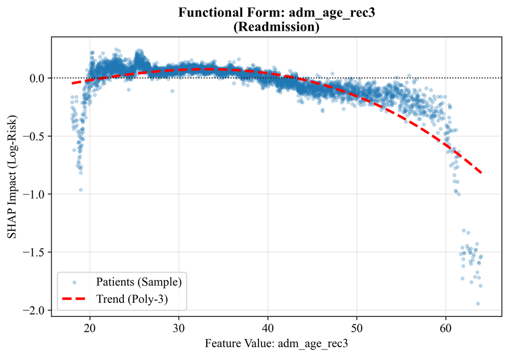

```
   📊 Plot generated: adm_age_rec3
```

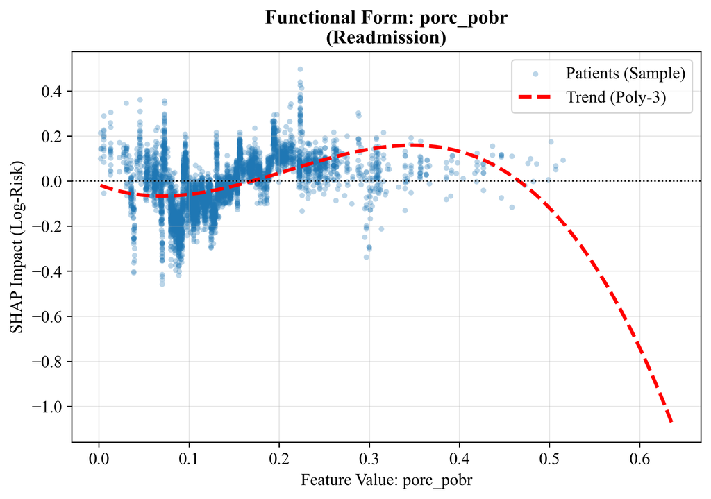

```
   📊 Plot generated: porc_pobr
```

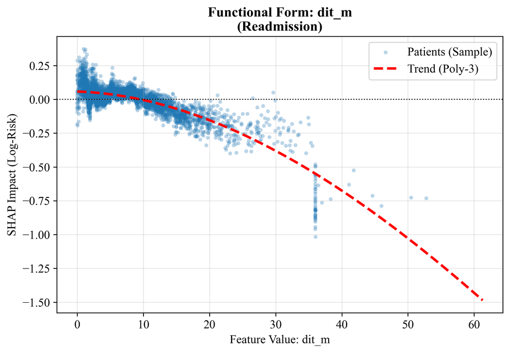

```
   📊 Plot generated: dit_m

🔍 Risk: Death
```

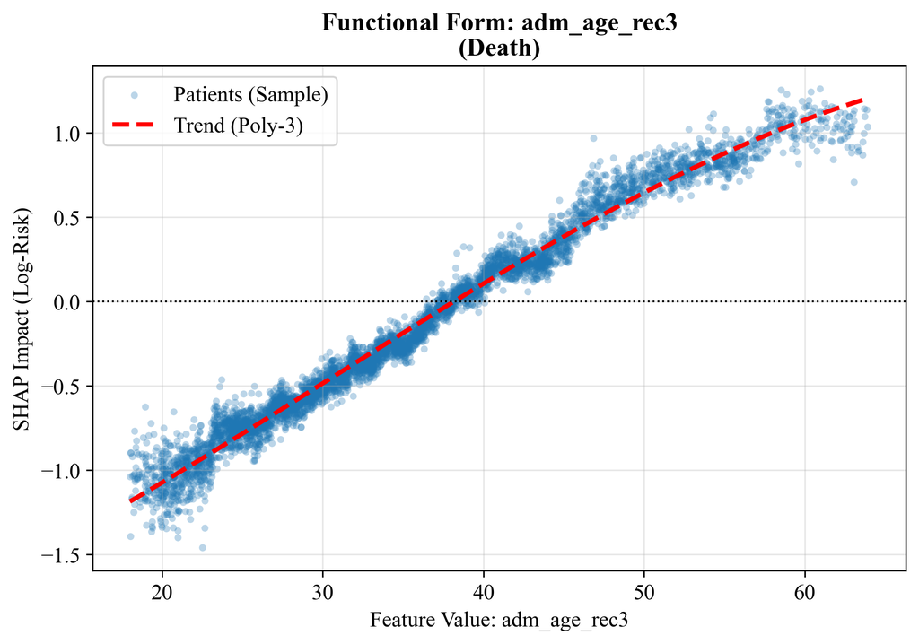

```
   📊 Plot generated: adm_age_rec3
```

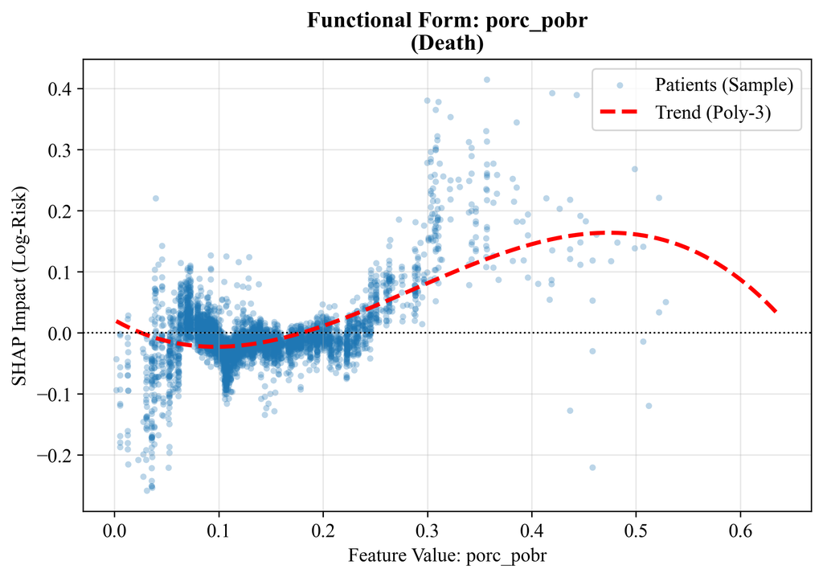

```
   📊 Plot generated: porc_pobr
```

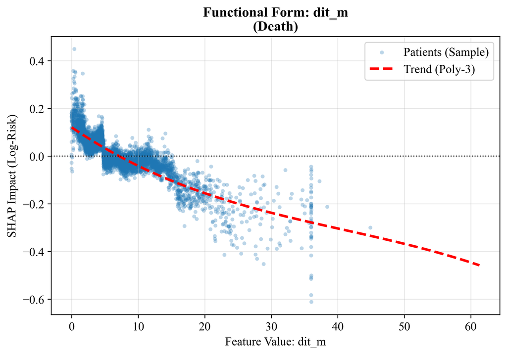

```
   📊 Plot generated: dit_m

✅ Analysis Complete. Excel file saved: XGB12_Functional_Forms_Dual_20260206_1531.xlsx
```

```python
#@title ⚡ Step 12: Functional Form Analysis (XGBoost - DUAL SHAP)

import shap
import pickle
import numpy as np
import pandas as pd
import matplotlib.pyplot as plt
import matplotlib as mpl
from datetime import datetime
import glob

# --- 1. CONFIGURATION ---
CONTINUOUS_VARS = ['adm_age_rec3', 'porc_pobr', 'dit_m']
timestamp = datetime.now().strftime("%Y%m%d_%H%M")
excel_filename = f"XGB12_Functional_Forms_Dual_{timestamp}.xlsx"

# Plotting Style
mpl.rcParams.update({
    "font.family": "serif",
    "font.serif": ["Times New Roman", "Times", "Nimbus Roman", "DejaVu Serif"],
    "pdf.fonttype": 42,
    "ps.fonttype": 42,
    "font.size": 12,
    "axes.grid": True,
    "grid.alpha": 0.3
})

# --- 2. LOAD DATA ---
try:
    print("🔄 Loading DUAL SHAP Data...")
    shap_files = sorted(glob.glob("xgb6_DUAL_SHAP_Aggregated_*.pkl"))

    if not shap_files:
        shap_files = sorted(glob.glob("xgb6_cvshap_SHAP_Aggregated_*.pkl"))

    if not shap_files:
        raise FileNotFoundError("❌ No Aggregated SHAP file found! Please run Step 5 (Dual Analysis) first.")

    shap_file = shap_files[-1]
    print(f"   Using: {shap_file}")

    with open(shap_file, 'rb') as f:
        data = pickle.load(f)

    X_all = data['X_all']
    feature_names = data['feature_names']

    # Store SHAP matrices
    shap_arrays = {}
    if 'shap_r_all' in data: shap_arrays['Readmission'] = data['shap_r_all']
    if 'shap_d_all' in data: shap_arrays['Death'] = data['shap_d_all']
    if 'shap_all' in data and not shap_arrays: shap_arrays['Readmission'] = data['shap_all'] # Fallback

    print(f"✅ Loaded SHAP data for: {list(shap_arrays.keys())}")
    print(f"   Total Patients: {X_all.shape[0]}")

    # Identify Column Indices
    var_indices = {}
    for v in CONTINUOUS_VARS:
        if v in feature_names:
            var_indices[v] = feature_names.index(v)
        else:
            print(f"⚠️ Warning: Variable '{v}' not found in feature list. Skipping.")

except Exception as e:
    print(f"❌ Error loading data: {e}")
    raise

# --- 3. ANALYSIS LOOP ---
writer = pd.ExcelWriter(excel_filename, engine='xlsxwriter')

print(f"⚡ Analyzing Functional Forms for: {list(var_indices.keys())}...")

for risk_name, vals in shap_arrays.items():
    print(f"\n🔍 Risk: {risk_name}")

    sheet_data = {}

    for var_name, var_idx in var_indices.items():
        # Extract X (Feature Value)
        if isinstance(X_all, pd.DataFrame):
            x_vals = X_all.iloc[:, var_idx].values
        else:
            x_vals = X_all[:, var_idx]

        # Extract Y (SHAP Impact) for specific risk
        y_vals = vals[:, var_idx]

        # Store Data for Excel
        sheet_data[f"{var_name}_Value"] = x_vals
        sheet_data[f"{var_name}_SHAP"] = y_vals

        # C. Generate Plot
        plt.figure(figsize=(8, 5))

        # Scatter (Downsample if huge for plotting speed/clarity)
        if len(x_vals) > 5000:
            idx = np.random.choice(len(x_vals), 5000, replace=False)
            plt.scatter(x_vals[idx], y_vals[idx], alpha=0.3, c='#1f77b4', edgecolors='none', s=15, label='Patients (Sample)')
        else:
            plt.scatter(x_vals, y_vals, alpha=0.5, c='#1f77b4', edgecolors='none', s=20, label='Patients')

        # Polynomial Trend (Degree 3)
        try:
            # Fit on full data
            z = np.polyfit(x_vals, y_vals, 3)
            p = np.poly1d(z)

            # Plot line
            x_range = np.linspace(x_vals.min(), x_vals.max(), 100)
            plt.plot(x_range, p(x_range), "r--", linewidth=2.5, label="Trend (Poly-3)")
        except:
            pass

        plt.title(f"Functional Form: {var_name}\n({risk_name})", fontsize=14, fontweight='bold')
        plt.xlabel(f"Feature Value: {var_name}", fontsize=12)
        plt.ylabel(f"SHAP Impact (Log-Risk)", fontsize=12)
        plt.axhline(0, color='k', linestyle=':', linewidth=1)
        plt.legend()

        # Save Plot
        fname = f"XGB12_FuncForm_{risk_name}_{var_name}_{timestamp}"
        plt.savefig(f"{fname}.png", dpi=300, bbox_inches='tight')
        plt.savefig(f"{fname}.pdf", bbox_inches='tight')
        plt.show()
        print(f"   📊 Plot generated: {var_name}")

    # D. Save to Excel
    if sheet_data:
        df_sheet = pd.DataFrame(sheet_data)
        writer_sheet_name = f"{risk_name}_Forms"
        df_sheet.to_excel(writer, sheet_name=writer_sheet_name, index=False)

# Close Writer
writer.close()
print(f"\n✅ Analysis Complete. Excel file saved: {excel_filename}")

# Fail-safe download
try:
    from google.colab import files
    files.download(excel_filename)
except:
    pass
```